# 5. Ders: Olasılık II

Çalışma soruları

← Çalışma soruları · Sunum

## Kavramları yoklama

$A$: öğrencinin dersten geçmesi; $B$: öğrencinin derslerin çoğuna devam etmesi. Aşağıdaki cümleler hangi olasılığı veriyor?

- “Öğrencilerin %48’i hem derslerin çoğuna devam etmiş hem dersten geçmiştir.”
- “Derslerin çoğuna devam edenlerin %85’i dersten geçer.”

İpucu: cümlede **“… olanların / … arasında”** diye başlayan kısım koşuldur ve dikey çizginin **sağına** yazılır; oranın paydasıdır.

- “Öğrencilerin %48’i hem derslerin çoğuna devam etmiş hem dersten geçmiştir.” → $\mathbb{P}(A \cap B)$. Bütün birimler içinde ikisinin birlikte gerçekleştiklerinin oranı: payda herkes.
- “Derslerin çoğuna devam edenlerin %85’i dersten geçer.” → $\mathbb{P}(A \mid B)$. $B$ gerçekleşmiş olanların içinde $A$’nın oranı: payda $B$.

$\mathbb{P}(A \mid B)$ ile $\mathbb{P}(B \mid A)$’nın payı aynıdır ($\mathbb{P}(A \cap B)$), paydaları farklıdır. Bu yüzden biri yüksekken öteki düşük olabilir: bu bağlamdaki dört sayı buna bir örnektir.

$A$: ürünün kusurlu olması; $B$: ürünün B makinesinde üretilmiş olması. Aşağıdaki cümleler hangi olasılığı veriyor?

- “Kusurlu ürünlerin %62’si B makinesinde üretilmiştir.”
- “Bütün ürünlerin %2’si hem B makinesinde üretilmiş hem de kusurludur.”

İpucu: cümlede **“… olanların / … arasında”** diye başlayan kısım koşuldur ve dikey çizginin **sağına** yazılır; oranın paydasıdır.

- “Kusurlu ürünlerin %62’si B makinesinde üretilmiştir.” → $\mathbb{P}(B \mid A)$. $A$ gerçekleşmiş olanların içinde $B$’nin oranı: payda $A$.
- “Bütün ürünlerin %2’si hem B makinesinde üretilmiş hem de kusurludur.” → $\mathbb{P}(A \cap B)$. Bütün birimler içinde ikisinin birlikte gerçekleştiklerinin oranı: payda herkes.

$\mathbb{P}(A \mid B)$ ile $\mathbb{P}(B \mid A)$’nın payı aynıdır ($\mathbb{P}(A \cap B)$), paydaları farklıdır. Bu yüzden biri yüksekken öteki düşük olabilir: bu bağlamdaki dört sayı buna bir örnektir.

$A$: ürünün kusurlu olması; $B$: ürünün B makinesinde üretilmiş olması. Aşağıdaki cümleler hangi olasılığı veriyor?

- “B makinesinde üretilen ürünlerin %5’i kusurludur.”
- “Bütün ürünlerin %3.2’si kusurludur.”

İpucu: cümlede **“… olanların / … arasında”** diye başlayan kısım koşuldur ve dikey çizginin **sağına** yazılır; oranın paydasıdır.

- “B makinesinde üretilen ürünlerin %5’i kusurludur.” → $\mathbb{P}(A \mid B)$. $B$ gerçekleşmiş olanların içinde $A$’nın oranı: payda $B$.
- “Bütün ürünlerin %3.2’si kusurludur.” → $\mathbb{P}(A)$. Bütün birimler içinde $A$’nın oranı; koşul yok.

$\mathbb{P}(A \mid B)$ ile $\mathbb{P}(B \mid A)$’nın payı aynıdır ($\mathbb{P}(A \cap B)$), paydaları farklıdır. Bu yüzden biri yüksekken öteki düşük olabilir: bu bağlamdaki dört sayı buna bir örnektir.

$A$: kişinin hasta olması; $B$: testin pozitif çıkması. Aşağıdaki cümleler hangi olasılığı veriyor?

- “Hastaların %95’inde test pozitif çıkar.”
- “Toplumun %2’si hastadır.”

İpucu: cümlede **“… olanların / … arasında”** diye başlayan kısım koşuldur ve dikey çizginin **sağına** yazılır; oranın paydasıdır.

- “Hastaların %95’inde test pozitif çıkar.” → $\mathbb{P}(B \mid A)$. $A$ gerçekleşmiş olanların içinde $B$’nin oranı: payda $A$.
- “Toplumun %2’si hastadır.” → $\mathbb{P}(A)$. Bütün birimler içinde $A$’nın oranı; koşul yok.

$\mathbb{P}(A \mid B)$ ile $\mathbb{P}(B \mid A)$’nın payı aynıdır ($\mathbb{P}(A \cap B)$), paydaları farklıdır. Bu yüzden biri yüksekken öteki düşük olabilir: bu bağlamdaki dört sayı buna bir örnektir.

$A$: öğrencinin dersten geçmesi; $B$: öğrencinin derslerin çoğuna devam etmesi. Aşağıdaki cümleler hangi olasılığı veriyor?

- “Derslerin çoğuna devam edenlerin %85’i dersten geçer.”
- “Dersten geçenlerin %70’i derslerin çoğuna devam etmiştir.”

İpucu: cümlede **“… olanların / … arasında”** diye başlayan kısım koşuldur ve dikey çizginin **sağına** yazılır; oranın paydasıdır.

- “Derslerin çoğuna devam edenlerin %85’i dersten geçer.” → $\mathbb{P}(A \mid B)$. $B$ gerçekleşmiş olanların içinde $A$’nın oranı: payda $B$.
- “Dersten geçenlerin %70’i derslerin çoğuna devam etmiştir.” → $\mathbb{P}(B \mid A)$. $A$ gerçekleşmiş olanların içinde $B$’nin oranı: payda $A$.

$\mathbb{P}(A \mid B)$ ile $\mathbb{P}(B \mid A)$’nın payı aynıdır ($\mathbb{P}(A \cap B)$), paydaları farklıdır. Bu yüzden biri yüksekken öteki düşük olabilir: bu bağlamdaki dört sayı buna bir örnektir.

$A$: kişinin hasta olması; $B$: testin pozitif çıkması. Aşağıdaki cümleler hangi olasılığı veriyor?

- “Hastaların %95’inde test pozitif çıkar.”
- “Toplumun %2’si hastadır.”

İpucu: cümlede **“… olanların / … arasında”** diye başlayan kısım koşuldur ve dikey çizginin **sağına** yazılır; oranın paydasıdır.

- “Hastaların %95’inde test pozitif çıkar.” → $\mathbb{P}(B \mid A)$. $A$ gerçekleşmiş olanların içinde $B$’nin oranı: payda $A$.
- “Toplumun %2’si hastadır.” → $\mathbb{P}(A)$. Bütün birimler içinde $A$’nın oranı; koşul yok.

$\mathbb{P}(A \mid B)$ ile $\mathbb{P}(B \mid A)$’nın payı aynıdır ($\mathbb{P}(A \cap B)$), paydaları farklıdır. Bu yüzden biri yüksekken öteki düşük olabilir: bu bağlamdaki dört sayı buna bir örnektir.

$A$: ürünün kusurlu olması; $B$: ürünün B makinesinde üretilmiş olması. Aşağıdaki cümleler hangi olasılığı veriyor?

- “Bütün ürünlerin %2’si hem B makinesinde üretilmiş hem de kusurludur.”
- “Kusurlu ürünlerin %62’si B makinesinde üretilmiştir.”

İpucu: cümlede **“… olanların / … arasında”** diye başlayan kısım koşuldur ve dikey çizginin **sağına** yazılır; oranın paydasıdır.

- “Bütün ürünlerin %2’si hem B makinesinde üretilmiş hem de kusurludur.” → $\mathbb{P}(A \cap B)$. Bütün birimler içinde ikisinin birlikte gerçekleştiklerinin oranı: payda herkes.
- “Kusurlu ürünlerin %62’si B makinesinde üretilmiştir.” → $\mathbb{P}(B \mid A)$. $A$ gerçekleşmiş olanların içinde $B$’nin oranı: payda $A$.

$\mathbb{P}(A \mid B)$ ile $\mathbb{P}(B \mid A)$’nın payı aynıdır ($\mathbb{P}(A \cap B)$), paydaları farklıdır. Bu yüzden biri yüksekken öteki düşük olabilir: bu bağlamdaki dört sayı buna bir örnektir.

$A$: öğrencinin dersten geçmesi; $B$: öğrencinin derslerin çoğuna devam etmesi. Aşağıdaki cümleler hangi olasılığı veriyor?

- “Dersten geçenlerin %70’i derslerin çoğuna devam etmiştir.”
- “Derslerin çoğuna devam edenlerin %85’i dersten geçer.”

İpucu: cümlede **“… olanların / … arasında”** diye başlayan kısım koşuldur ve dikey çizginin **sağına** yazılır; oranın paydasıdır.

- “Dersten geçenlerin %70’i derslerin çoğuna devam etmiştir.” → $\mathbb{P}(B \mid A)$. $A$ gerçekleşmiş olanların içinde $B$’nin oranı: payda $A$.
- “Derslerin çoğuna devam edenlerin %85’i dersten geçer.” → $\mathbb{P}(A \mid B)$. $B$ gerçekleşmiş olanların içinde $A$’nın oranı: payda $B$.

$\mathbb{P}(A \mid B)$ ile $\mathbb{P}(B \mid A)$’nın payı aynıdır ($\mathbb{P}(A \cap B)$), paydaları farklıdır. Bu yüzden biri yüksekken öteki düşük olabilir: bu bağlamdaki dört sayı buna bir örnektir.

Hilesiz bir zar atılıyor. $A$: zarın 4 ya da daha büyük gelmesi; $B$: zarın 3’e tam bölünmesi.

- $\mathbb{P}(A \cap B)$ (dört ondalık):
- $A$ ile $B$ ayrık mı?
- $A$ ile $B$ bağımsız mı?

$A = \{4, 5, 6\}$, $B = \{3, 6\}$, $A \cap B = \{6\}$.

$\mathbb{P}(A) = 3/6$, $\mathbb{P}(B) = 2/6$, $\mathbb{P}(A \cap B) = 1/6 = 0.1667$.

- **Ayrık mı?** Hayır: ortak sonuçları var.
- **Bağımsız mı?** $\mathbb{P}(A)\,\mathbb{P}(B) = 3/6 \times 2/6 = 0.1667$ ve bu $\mathbb{P}(A \cap B)$’ye **eşit**: bağımsız. $B$’nin gerçekleştiğini bilmek $A$’nın olasılığını değiştirmiyor.

Ayrıklık kümelerle ilgili bir özelliktir (ortak sonuç var mı?); bağımsızlık ise olasılıklar arasındaki bir ilişkidir. İkisi farklı kavramlardır.

Hilesiz bir zar atılıyor. $A$: zarın tek gelmesi; $B$: zarın 4 ya da daha büyük gelmesi.

- $\mathbb{P}(A \cap B)$ (dört ondalık):
- $A$ ile $B$ ayrık mı?
- $A$ ile $B$ bağımsız mı?

$A = \{1, 3, 5\}$, $B = \{4, 5, 6\}$, $A \cap B = \{5\}$.

$\mathbb{P}(A) = 3/6$, $\mathbb{P}(B) = 3/6$, $\mathbb{P}(A \cap B) = 1/6 = 0.1667$.

- **Ayrık mı?** Hayır: ortak sonuçları var.
- **Bağımsız mı?** $\mathbb{P}(A)\,\mathbb{P}(B) = 3/6 \times 3/6 = 0.2500$ ve bu $\mathbb{P}(A \cap B)$’den **farklı**: bağımsız değil.

Ayrıklık kümelerle ilgili bir özelliktir (ortak sonuç var mı?); bağımsızlık ise olasılıklar arasındaki bir ilişkidir. İkisi farklı kavramlardır.

Hilesiz bir zar atılıyor. $A$: zarın 1 ya da 2 gelmesi; $B$: zarın çift gelmesi.

- $\mathbb{P}(A \cap B)$ (dört ondalık):
- $A$ ile $B$ ayrık mı?
- $A$ ile $B$ bağımsız mı?

$A = \{1, 2\}$, $B = \{2, 4, 6\}$, $A \cap B = \{2\}$.

$\mathbb{P}(A) = 2/6$, $\mathbb{P}(B) = 3/6$, $\mathbb{P}(A \cap B) = 1/6 = 0.1667$.

- **Ayrık mı?** Hayır: ortak sonuçları var.
- **Bağımsız mı?** $\mathbb{P}(A)\,\mathbb{P}(B) = 2/6 \times 3/6 = 0.1667$ ve bu $\mathbb{P}(A \cap B)$’ye **eşit**: bağımsız. $B$’nin gerçekleştiğini bilmek $A$’nın olasılığını değiştirmiyor.

Ayrıklık kümelerle ilgili bir özelliktir (ortak sonuç var mı?); bağımsızlık ise olasılıklar arasındaki bir ilişkidir. İkisi farklı kavramlardır.

Hilesiz bir zar atılıyor. $A$: zarın tek gelmesi; $B$: zarın 3’e tam bölünmesi.

- $\mathbb{P}(A \cap B)$ (dört ondalık):
- $A$ ile $B$ ayrık mı?
- $A$ ile $B$ bağımsız mı?

$A = \{1, 3, 5\}$, $B = \{3, 6\}$, $A \cap B = \{3\}$.

$\mathbb{P}(A) = 3/6$, $\mathbb{P}(B) = 2/6$, $\mathbb{P}(A \cap B) = 1/6 = 0.1667$.

- **Ayrık mı?** Hayır: ortak sonuçları var.
- **Bağımsız mı?** $\mathbb{P}(A)\,\mathbb{P}(B) = 3/6 \times 2/6 = 0.1667$ ve bu $\mathbb{P}(A \cap B)$’ye **eşit**: bağımsız. $B$’nin gerçekleştiğini bilmek $A$’nın olasılığını değiştirmiyor.

Ayrıklık kümelerle ilgili bir özelliktir (ortak sonuç var mı?); bağımsızlık ise olasılıklar arasındaki bir ilişkidir. İkisi farklı kavramlardır.

Hilesiz bir zar atılıyor. $A$: zarın 6 gelmesi; $B$: zarın 4’ten küçük gelmesi.

- $\mathbb{P}(A \cap B)$ (dört ondalık):
- $A$ ile $B$ ayrık mı?
- $A$ ile $B$ bağımsız mı?

$A = \{6\}$, $B = \{1, 2, 3\}$, $A \cap B = \emptyset$.

$\mathbb{P}(A) = 1/6$, $\mathbb{P}(B) = 3/6$, $\mathbb{P}(A \cap B) = 0/6 = 0.0000$.

- **Ayrık mı?** Evet: ortak sonuç yok, kesişim boş küme.
- **Bağımsız mı?** $\mathbb{P}(A)\,\mathbb{P}(B) = 1/6 \times 3/6 = 0.0833$ ve bu $\mathbb{P}(A \cap B)$’den **farklı**: bağımsız değil.

Olasılıkları sıfırdan büyük iki ayrık olay bağımsız **olamaz**: biri gerçekleşince öteki kesinlikle gerçekleşmez, yani $\mathbb{P}(B \mid A) = 0 \neq \mathbb{P}(B)$. Ayrık olaylar birbiri hakkında tam bilgi taşır.

Hilesiz bir zar atılıyor. $A$: zarın tek gelmesi; $B$: zarın 4’ten küçük gelmesi.

- $\mathbb{P}(A \cap B)$ (dört ondalık):
- $A$ ile $B$ ayrık mı?
- $A$ ile $B$ bağımsız mı?

$A = \{1, 3, 5\}$, $B = \{1, 2, 3\}$, $A \cap B = \{1, 3\}$.

$\mathbb{P}(A) = 3/6$, $\mathbb{P}(B) = 3/6$, $\mathbb{P}(A \cap B) = 2/6 = 0.3333$.

- **Ayrık mı?** Hayır: ortak sonuçları var.
- **Bağımsız mı?** $\mathbb{P}(A)\,\mathbb{P}(B) = 3/6 \times 3/6 = 0.2500$ ve bu $\mathbb{P}(A \cap B)$’den **farklı**: bağımsız değil.

Ayrıklık kümelerle ilgili bir özelliktir (ortak sonuç var mı?); bağımsızlık ise olasılıklar arasındaki bir ilişkidir. İkisi farklı kavramlardır.

Hilesiz bir zar atılıyor. $A$: zarın tek gelmesi; $B$: zarın 4’ten küçük gelmesi.

- $\mathbb{P}(A \cap B)$ (dört ondalık):
- $A$ ile $B$ ayrık mı?
- $A$ ile $B$ bağımsız mı?

$A = \{1, 3, 5\}$, $B = \{1, 2, 3\}$, $A \cap B = \{1, 3\}$.

$\mathbb{P}(A) = 3/6$, $\mathbb{P}(B) = 3/6$, $\mathbb{P}(A \cap B) = 2/6 = 0.3333$.

- **Ayrık mı?** Hayır: ortak sonuçları var.
- **Bağımsız mı?** $\mathbb{P}(A)\,\mathbb{P}(B) = 3/6 \times 3/6 = 0.2500$ ve bu $\mathbb{P}(A \cap B)$’den **farklı**: bağımsız değil.

Ayrıklık kümelerle ilgili bir özelliktir (ortak sonuç var mı?); bağımsızlık ise olasılıklar arasındaki bir ilişkidir. İkisi farklı kavramlardır.

Hilesiz bir zar atılıyor. $A$: zarın 6 gelmesi; $B$: zarın 1, 2, 3 ya da 4 gelmesi.

- $\mathbb{P}(A \cap B)$ (dört ondalık):
- $A$ ile $B$ ayrık mı?
- $A$ ile $B$ bağımsız mı?

$A = \{6\}$, $B = \{1, 2, 3, 4\}$, $A \cap B = \emptyset$.

$\mathbb{P}(A) = 1/6$, $\mathbb{P}(B) = 4/6$, $\mathbb{P}(A \cap B) = 0/6 = 0.0000$.

- **Ayrık mı?** Evet: ortak sonuç yok, kesişim boş küme.
- **Bağımsız mı?** $\mathbb{P}(A)\,\mathbb{P}(B) = 1/6 \times 4/6 = 0.1111$ ve bu $\mathbb{P}(A \cap B)$’den **farklı**: bağımsız değil.

Olasılıkları sıfırdan büyük iki ayrık olay bağımsız **olamaz**: biri gerçekleşince öteki kesinlikle gerçekleşmez, yani $\mathbb{P}(B \mid A) = 0 \neq \mathbb{P}(B)$. Ayrık olaylar birbiri hakkında tam bilgi taşır.

$A$: borsanın bir günü artışla kapatması; $B$: o günün güneşli olması. $\mathbb{P}(A) = 0.25$, $\mathbb{P}(B) = 0.4$, $\mathbb{P}(A \cap B) = 0.05$.

- $\mathbb{P}(A \mid B)$ (dört ondalık):
- $A$ ile $B$ bağımsız mı?

$$\mathbb{P}(A \mid B) = \frac{\mathbb{P}(A \cap B)}{\mathbb{P}(B)} = \frac{0.05}{0.4} = 0.1250$$

Bağımsızlık için iki eşdeğer denetim var: $\mathbb{P}(A \mid B) = \mathbb{P}(A)$ mı, ya da $\mathbb{P}(A \cap B) = \mathbb{P}(A)\,\mathbb{P}(B)$ mi?

$\mathbb{P}(A)\,\mathbb{P}(B) = 0.25 \times 0.4 = 0.1$. Bu, $\mathbb{P}(A \cap B) = 0.05$ değerinden farklı; $\mathbb{P}(A \mid B) = 0.1250 \neq \mathbb{P}(A) = 0.25$. **Bağımsız değil**: $B$’yi bilmek $A$’nın olasılığını azaltıyor.

Bağımsız olmamaları birinin ötekine **yol açtığı** anlamına gelmez; bağımsızlık olasılıklar arasındaki bir ilişkidir, nedensellik ayrı bir sorudur.

$A$: bir öğrencinin yurtta kalması; $B$: öğrencinin birinci sınıfta olması. $\mathbb{P}(A) = 0.35$, $\mathbb{P}(B) = 0.2$, $\mathbb{P}(A \cap B) = 0.04$.

- $\mathbb{P}(A \mid B)$ (dört ondalık):
- $A$ ile $B$ bağımsız mı?

$$\mathbb{P}(A \mid B) = \frac{\mathbb{P}(A \cap B)}{\mathbb{P}(B)} = \frac{0.04}{0.2} = 0.2000$$

Bağımsızlık için iki eşdeğer denetim var: $\mathbb{P}(A \mid B) = \mathbb{P}(A)$ mı, ya da $\mathbb{P}(A \cap B) = \mathbb{P}(A)\,\mathbb{P}(B)$ mi?

$\mathbb{P}(A)\,\mathbb{P}(B) = 0.35 \times 0.2 = 0.07$. Bu, $\mathbb{P}(A \cap B) = 0.04$ değerinden farklı; $\mathbb{P}(A \mid B) = 0.2000 \neq \mathbb{P}(A) = 0.35$. **Bağımsız değil**: $B$’yi bilmek $A$’nın olasılığını azaltıyor.

Bağımsız olmamaları birinin ötekine **yol açtığı** anlamına gelmez; bağımsızlık olasılıklar arasındaki bir ilişkidir, nedensellik ayrı bir sorudur.

$A$: hanede sigara içilmesi; $B$: hanenin özel sağlık sigortasının olması. $\mathbb{P}(A) = 0.55$, $\mathbb{P}(B) = 0.4$, $\mathbb{P}(A \cap B) = 0.22$.

- $\mathbb{P}(A \mid B)$ (dört ondalık):
- $A$ ile $B$ bağımsız mı?

$$\mathbb{P}(A \mid B) = \frac{\mathbb{P}(A \cap B)}{\mathbb{P}(B)} = \frac{0.22}{0.4} = 0.5500$$

Bağımsızlık için iki eşdeğer denetim var: $\mathbb{P}(A \mid B) = \mathbb{P}(A)$ mı, ya da $\mathbb{P}(A \cap B) = \mathbb{P}(A)\,\mathbb{P}(B)$ mi?

$\mathbb{P}(A)\,\mathbb{P}(B) = 0.55 \times 0.4 = 0.22$. Bu $\mathbb{P}(A \cap B)$’ye eşit; $\mathbb{P}(A \mid B) = 0.5500 = \mathbb{P}(A)$. **Bağımsız**: $B$’yi bilmek $A$’nın olasılığını değiştirmiyor.

Bağımsız olmamaları birinin ötekine **yol açtığı** anlamına gelmez; bağımsızlık olasılıklar arasındaki bir ilişkidir, nedensellik ayrı bir sorudur.

$A$: bir öğrencinin yurtta kalması; $B$: öğrencinin birinci sınıfta olması. $\mathbb{P}(A) = 0.3$, $\mathbb{P}(B) = 0.3$, $\mathbb{P}(A \cap B) = 0.12$.

- $\mathbb{P}(A \mid B)$ (dört ondalık):
- $A$ ile $B$ bağımsız mı?

$$\mathbb{P}(A \mid B) = \frac{\mathbb{P}(A \cap B)}{\mathbb{P}(B)} = \frac{0.12}{0.3} = 0.4000$$

Bağımsızlık için iki eşdeğer denetim var: $\mathbb{P}(A \mid B) = \mathbb{P}(A)$ mı, ya da $\mathbb{P}(A \cap B) = \mathbb{P}(A)\,\mathbb{P}(B)$ mi?

$\mathbb{P}(A)\,\mathbb{P}(B) = 0.3 \times 0.3 = 0.09$. Bu, $\mathbb{P}(A \cap B) = 0.12$ değerinden farklı; $\mathbb{P}(A \mid B) = 0.4000 \neq \mathbb{P}(A) = 0.3$. **Bağımsız değil**: $B$’yi bilmek $A$’nın olasılığını artırıyor.

Bağımsız olmamaları birinin ötekine **yol açtığı** anlamına gelmez; bağımsızlık olasılıklar arasındaki bir ilişkidir, nedensellik ayrı bir sorudur.

## Uygulama ve yorum

### Koşullu olasılık ve çarpım kuralı

Bir öğrencinin vizeden geçmesi olasılığı 0.55, finalden geçmesi olasılığı 0.35, ikisinin birlikte gerçekleşme olasılığı 0.32. Dört ondalıkla:

- vizeden geçen bir öğrencinin finalden geçmesi olasılığı:
- finalden geçen bir öğrencinin vizeden geçmesi olasılığı:
- vizeden geçemeyen bir öğrencinin finalden geçmesi olasılığı:

$A$: vizeden geçmesi, $B$: finalden geçmesi. “vizeden geçen bir öğrencinin” demek $A$’nın gerçekleştiğini bilmek, yani $A$’ya koşullu olasılık.

$$\mathbb{P}(B \mid A) = \frac{\mathbb{P}(A \cap B)}{\mathbb{P}(A)} = \frac{0.32}{0.55} = 0.5818$$

$$\mathbb{P}(A \mid B) = \frac{\mathbb{P}(A \cap B)}{\mathbb{P}(B)} = \frac{0.32}{0.35} = 0.9143$$

Üçüncüsü için önce $\mathbb{P}(\bar{A} \cap B) = \mathbb{P}(B) - \mathbb{P}(A \cap B) = 0.35 - 0.32 = 0.03$ ve $\mathbb{P}(\bar{A}) = 1 - 0.55 = 0.45$:

$$\mathbb{P}(B \mid \bar{A}) = \frac{0.03}{0.45} = 0.0667$$

$\mathbb{P}(B \mid A)$ ile $\mathbb{P}(B \mid \bar{A})$’nın toplamının 1 olması gerekmez; birbirinin tümleyeni olan $\mathbb{P}(B \mid A)$ ile $\mathbb{P}(\bar{B} \mid A)$’dır.

Bir kullanıcının reklamı görmesi olasılığı 0.90, ürünü satın alması olasılığı 0.50, ikisinin birlikte gerçekleşme olasılığı 0.47. Dört ondalıkla:

- reklamı gören bir kullanıcının ürünü satın alması olasılığı:
- ürünü satın alan bir kullanıcının reklamı görmesi olasılığı:
- reklamı görmeyen bir kullanıcının ürünü satın alması olasılığı:

$A$: reklamı görmesi, $B$: ürünü satın alması. “reklamı gören bir kullanıcının” demek $A$’nın gerçekleştiğini bilmek, yani $A$’ya koşullu olasılık.

$$\mathbb{P}(B \mid A) = \frac{\mathbb{P}(A \cap B)}{\mathbb{P}(A)} = \frac{0.47}{0.90} = 0.5222$$

$$\mathbb{P}(A \mid B) = \frac{\mathbb{P}(A \cap B)}{\mathbb{P}(B)} = \frac{0.47}{0.50} = 0.9400$$

Üçüncüsü için önce $\mathbb{P}(\bar{A} \cap B) = \mathbb{P}(B) - \mathbb{P}(A \cap B) = 0.50 - 0.47 = 0.03$ ve $\mathbb{P}(\bar{A}) = 1 - 0.90 = 0.10$:

$$\mathbb{P}(B \mid \bar{A}) = \frac{0.03}{0.10} = 0.3000$$

$\mathbb{P}(B \mid A)$ ile $\mathbb{P}(B \mid \bar{A})$’nın toplamının 1 olması gerekmez; birbirinin tümleyeni olan $\mathbb{P}(B \mid A)$ ile $\mathbb{P}(\bar{B} \mid A)$’dır.

Bir kullanıcının reklamı görmesi olasılığı 0.55, ürünü satın alması olasılığı 0.70, ikisinin birlikte gerçekleşme olasılığı 0.41. Dört ondalıkla:

- reklamı gören bir kullanıcının ürünü satın alması olasılığı:
- ürünü satın alan bir kullanıcının reklamı görmesi olasılığı:
- reklamı görmeyen bir kullanıcının ürünü satın alması olasılığı:

$A$: reklamı görmesi, $B$: ürünü satın alması. “reklamı gören bir kullanıcının” demek $A$’nın gerçekleştiğini bilmek, yani $A$’ya koşullu olasılık.

$$\mathbb{P}(B \mid A) = \frac{\mathbb{P}(A \cap B)}{\mathbb{P}(A)} = \frac{0.41}{0.55} = 0.7455$$

$$\mathbb{P}(A \mid B) = \frac{\mathbb{P}(A \cap B)}{\mathbb{P}(B)} = \frac{0.41}{0.70} = 0.5857$$

Üçüncüsü için önce $\mathbb{P}(\bar{A} \cap B) = \mathbb{P}(B) - \mathbb{P}(A \cap B) = 0.70 - 0.41 = 0.29$ ve $\mathbb{P}(\bar{A}) = 1 - 0.55 = 0.45$:

$$\mathbb{P}(B \mid \bar{A}) = \frac{0.29}{0.45} = 0.6444$$

$\mathbb{P}(B \mid A)$ ile $\mathbb{P}(B \mid \bar{A})$’nın toplamının 1 olması gerekmez; birbirinin tümleyeni olan $\mathbb{P}(B \mid A)$ ile $\mathbb{P}(\bar{B} \mid A)$’dır.

Bir öğrencinin vizeden geçmesi olasılığı 0.40, finalden geçmesi olasılığı 0.45, ikisinin birlikte gerçekleşme olasılığı 0.10. Dört ondalıkla:

- vizeden geçen bir öğrencinin finalden geçmesi olasılığı:
- finalden geçen bir öğrencinin vizeden geçmesi olasılığı:
- vizeden geçemeyen bir öğrencinin finalden geçmesi olasılığı:

$A$: vizeden geçmesi, $B$: finalden geçmesi. “vizeden geçen bir öğrencinin” demek $A$’nın gerçekleştiğini bilmek, yani $A$’ya koşullu olasılık.

$$\mathbb{P}(B \mid A) = \frac{\mathbb{P}(A \cap B)}{\mathbb{P}(A)} = \frac{0.10}{0.40} = 0.2500$$

$$\mathbb{P}(A \mid B) = \frac{\mathbb{P}(A \cap B)}{\mathbb{P}(B)} = \frac{0.10}{0.45} = 0.2222$$

Üçüncüsü için önce $\mathbb{P}(\bar{A} \cap B) = \mathbb{P}(B) - \mathbb{P}(A \cap B) = 0.45 - 0.10 = 0.35$ ve $\mathbb{P}(\bar{A}) = 1 - 0.40 = 0.60$:

$$\mathbb{P}(B \mid \bar{A}) = \frac{0.35}{0.60} = 0.5833$$

$\mathbb{P}(B \mid A)$ ile $\mathbb{P}(B \mid \bar{A})$’nın toplamının 1 olması gerekmez; birbirinin tümleyeni olan $\mathbb{P}(B \mid A)$ ile $\mathbb{P}(\bar{B} \mid A)$’dır.

Bir torbada 7 kırmızı, 5 yeşil ve 3 mavi top var. Torbadan **yerine koymadan** art arda iki top rassal olarak çekiliyor. Dört ondalıkla:

- İki topun da kırmızı olma olasılığı:
- Birinci topun kırmızı, ikincisinin yeşil olma olasılığı:
- İki topun aynı renkte olma olasılığı:

Çarpım kuralı: $\mathbb{P}(A_1 \cap A_2) = \mathbb{P}(A_1)\,\mathbb{P}(A_2 \mid A_1)$. Yerine koyulmadığı için ikinci çekilişte torbada 14 top kalır ve olasılık birinci çekilişin sonucuna **bağlıdır**.

- **İki kırmızı:** $\dfrac{7}{15} \times \dfrac{6}{14} = 0.2000$
- **Önce kırmızı, sonra yeşil:** $\dfrac{7}{15} \times \dfrac{5}{14} = 0.1667$ (birinci kırmızı çıkınca yeşiller eksilmez)
- **Aynı renk:** “iki kırmızı”, “iki yeşil” ve “iki mavi” ayrık olaylardır; olasılıkları toplanır:
  $$\frac{7 \cdot 6 + 5 \cdot 4 + 3 \cdot 2}{15 \cdot 14} = \frac{68}{210} = 0.3238$$

Aynı sonuç kombinasyonla da bulunur: iki kırmızı için $\binom{7}{2} / \binom{15}{2} = 21 / 105 = 0.2000$.

Bir torbada 3 kırmızı, 3 yeşil ve 3 mavi top var. Torbadan **yerine koymadan** art arda iki top rassal olarak çekiliyor. Dört ondalıkla:

- İki topun da kırmızı olma olasılığı:
- Birinci topun kırmızı, ikincisinin yeşil olma olasılığı:
- İki topun aynı renkte olma olasılığı:

Çarpım kuralı: $\mathbb{P}(A_1 \cap A_2) = \mathbb{P}(A_1)\,\mathbb{P}(A_2 \mid A_1)$. Yerine koyulmadığı için ikinci çekilişte torbada 8 top kalır ve olasılık birinci çekilişin sonucuna **bağlıdır**.

- **İki kırmızı:** $\dfrac{3}{9} \times \dfrac{2}{8} = 0.0833$
- **Önce kırmızı, sonra yeşil:** $\dfrac{3}{9} \times \dfrac{3}{8} = 0.1250$ (birinci kırmızı çıkınca yeşiller eksilmez)
- **Aynı renk:** “iki kırmızı”, “iki yeşil” ve “iki mavi” ayrık olaylardır; olasılıkları toplanır:
  $$\frac{3 \cdot 2 + 3 \cdot 2 + 3 \cdot 2}{9 \cdot 8} = \frac{18}{72} = 0.2500$$

Aynı sonuç kombinasyonla da bulunur: iki kırmızı için $\binom{3}{2} / \binom{9}{2} = 3 / 36 = 0.0833$.

Bir torbada 4 kırmızı, 4 yeşil ve 4 mavi top var. Torbadan **yerine koymadan** art arda iki top rassal olarak çekiliyor. Dört ondalıkla:

- İki topun da kırmızı olma olasılığı:
- Birinci topun kırmızı, ikincisinin yeşil olma olasılığı:
- İki topun aynı renkte olma olasılığı:

Çarpım kuralı: $\mathbb{P}(A_1 \cap A_2) = \mathbb{P}(A_1)\,\mathbb{P}(A_2 \mid A_1)$. Yerine koyulmadığı için ikinci çekilişte torbada 11 top kalır ve olasılık birinci çekilişin sonucuna **bağlıdır**.

- **İki kırmızı:** $\dfrac{4}{12} \times \dfrac{3}{11} = 0.0909$
- **Önce kırmızı, sonra yeşil:** $\dfrac{4}{12} \times \dfrac{4}{11} = 0.1212$ (birinci kırmızı çıkınca yeşiller eksilmez)
- **Aynı renk:** “iki kırmızı”, “iki yeşil” ve “iki mavi” ayrık olaylardır; olasılıkları toplanır:
  $$\frac{4 \cdot 3 + 4 \cdot 3 + 4 \cdot 3}{12 \cdot 11} = \frac{36}{132} = 0.2727$$

Aynı sonuç kombinasyonla da bulunur: iki kırmızı için $\binom{4}{2} / \binom{12}{2} = 6 / 66 = 0.0909$.

Bir torbada 6 kırmızı, 5 yeşil ve 3 mavi top var. Torbadan **yerine koymadan** art arda iki top rassal olarak çekiliyor. Dört ondalıkla:

- İki topun da kırmızı olma olasılığı:
- Birinci topun kırmızı, ikincisinin yeşil olma olasılığı:
- İki topun aynı renkte olma olasılığı:

Çarpım kuralı: $\mathbb{P}(A_1 \cap A_2) = \mathbb{P}(A_1)\,\mathbb{P}(A_2 \mid A_1)$. Yerine koyulmadığı için ikinci çekilişte torbada 13 top kalır ve olasılık birinci çekilişin sonucuna **bağlıdır**.

- **İki kırmızı:** $\dfrac{6}{14} \times \dfrac{5}{13} = 0.1648$
- **Önce kırmızı, sonra yeşil:** $\dfrac{6}{14} \times \dfrac{5}{13} = 0.1648$ (birinci kırmızı çıkınca yeşiller eksilmez)
- **Aynı renk:** “iki kırmızı”, “iki yeşil” ve “iki mavi” ayrık olaylardır; olasılıkları toplanır:
  $$\frac{6 \cdot 5 + 5 \cdot 4 + 3 \cdot 2}{14 \cdot 13} = \frac{56}{182} = 0.3077$$

Aynı sonuç kombinasyonla da bulunur: iki kırmızı için $\binom{6}{2} / \binom{14}{2} = 15 / 91 = 0.1648$.

Bir torbada 3 kırmızı ve 3 sarı top var. Torbadan **yerine koyarak** üç top rassal olarak çekiliyor (her çekilişten sonra top torbaya geri atılıyor). Dört ondalıkla:

- Üç topun da aynı renkte olma olasılığı:
- En az iki sarı top gelme olasılığı:

Top her seferinde geri konduğu için torba hep aynıdır: çekilişler **bağımsızdır** ve her çekilişte $\mathbb{P}(K) = 3/6$, $\mathbb{P}(S) = 3/6$. Bağımsız olayların kesişiminin olasılığı olasılıkların çarpımıdır.

- **Aynı renk:** “üçü kırmızı” ile “üçü sarı” ayrık:
  $$\left(\frac{3}{6}\right)^3 + \left(\frac{3}{6}\right)^3 = 0.1250 + 0.1250 = 0.2500$$
- **En az iki sarı:** tam iki sarı ya da üç sarı. Tam iki sarının üç dizilimi var ($SSK$, $SKS$, $KSS$), her birinin olasılığı $(3/6)^2 (3/6)$:
  $$3 \left(\frac{3}{6}\right)^2 \frac{3}{6} + \left(\frac{3}{6}\right)^3 = 0.3750 + 0.1250 = 0.5000$$

Yerine koymadan çekilseydi çekilişler bağımsız olmazdı; ikinci çekilişin olasılıkları birincinin sonucuna bağlı olurdu.

Bir torbada 6 kırmızı ve 3 sarı top var. Torbadan **yerine koyarak** üç top rassal olarak çekiliyor (her çekilişten sonra top torbaya geri atılıyor). Dört ondalıkla:

- Üç topun da aynı renkte olma olasılığı:
- En az iki sarı top gelme olasılığı:

Top her seferinde geri konduğu için torba hep aynıdır: çekilişler **bağımsızdır** ve her çekilişte $\mathbb{P}(K) = 6/9$, $\mathbb{P}(S) = 3/9$. Bağımsız olayların kesişiminin olasılığı olasılıkların çarpımıdır.

- **Aynı renk:** “üçü kırmızı” ile “üçü sarı” ayrık:
  $$\left(\frac{6}{9}\right)^3 + \left(\frac{3}{9}\right)^3 = 0.2963 + 0.0370 = 0.3333$$
- **En az iki sarı:** tam iki sarı ya da üç sarı. Tam iki sarının üç dizilimi var ($SSK$, $SKS$, $KSS$), her birinin olasılığı $(3/9)^2 (6/9)$:
  $$3 \left(\frac{3}{9}\right)^2 \frac{6}{9} + \left(\frac{3}{9}\right)^3 = 0.2222 + 0.0370 = 0.2593$$

Yerine koymadan çekilseydi çekilişler bağımsız olmazdı; ikinci çekilişin olasılıkları birincinin sonucuna bağlı olurdu.

Bir torbada 3 kırmızı ve 2 sarı top var. Torbadan **yerine koyarak** üç top rassal olarak çekiliyor (her çekilişten sonra top torbaya geri atılıyor). Dört ondalıkla:

- Üç topun da aynı renkte olma olasılığı:
- En az iki sarı top gelme olasılığı:

Top her seferinde geri konduğu için torba hep aynıdır: çekilişler **bağımsızdır** ve her çekilişte $\mathbb{P}(K) = 3/5$, $\mathbb{P}(S) = 2/5$. Bağımsız olayların kesişiminin olasılığı olasılıkların çarpımıdır.

- **Aynı renk:** “üçü kırmızı” ile “üçü sarı” ayrık:
  $$\left(\frac{3}{5}\right)^3 + \left(\frac{2}{5}\right)^3 = 0.2160 + 0.0640 = 0.2800$$
- **En az iki sarı:** tam iki sarı ya da üç sarı. Tam iki sarının üç dizilimi var ($SSK$, $SKS$, $KSS$), her birinin olasılığı $(2/5)^2 (3/5)$:
  $$3 \left(\frac{2}{5}\right)^2 \frac{3}{5} + \left(\frac{2}{5}\right)^3 = 0.2880 + 0.0640 = 0.3520$$

Yerine koymadan çekilseydi çekilişler bağımsız olmazdı; ikinci çekilişin olasılıkları birincinin sonucuna bağlı olurdu.

Bir torbada 4 kırmızı ve 4 sarı top var. Torbadan **yerine koyarak** üç top rassal olarak çekiliyor (her çekilişten sonra top torbaya geri atılıyor). Dört ondalıkla:

- Üç topun da aynı renkte olma olasılığı:
- En az iki sarı top gelme olasılığı:

Top her seferinde geri konduğu için torba hep aynıdır: çekilişler **bağımsızdır** ve her çekilişte $\mathbb{P}(K) = 4/8$, $\mathbb{P}(S) = 4/8$. Bağımsız olayların kesişiminin olasılığı olasılıkların çarpımıdır.

- **Aynı renk:** “üçü kırmızı” ile “üçü sarı” ayrık:
  $$\left(\frac{4}{8}\right)^3 + \left(\frac{4}{8}\right)^3 = 0.1250 + 0.1250 = 0.2500$$
- **En az iki sarı:** tam iki sarı ya da üç sarı. Tam iki sarının üç dizilimi var ($SSK$, $SKS$, $KSS$), her birinin olasılığı $(4/8)^2 (4/8)$:
  $$3 \left(\frac{4}{8}\right)^2 \frac{4}{8} + \left(\frac{4}{8}\right)^3 = 0.3750 + 0.1250 = 0.5000$$

Yerine koymadan çekilseydi çekilişler bağımsız olmazdı; ikinci çekilişin olasılıkları birincinin sonucuna bağlı olurdu.

$A$: döviz kurunun yükselmesi; $B$: ihracatın artması. $\mathbb{P}(A) = 0.15$, $\mathbb{P}(B) = 0.45$ ve kurun yükselmesi durumunda ihracatın artması olasılığı $\mathbb{P}(B \mid A) = 0.75$. Dört ondalıkla:

- $\mathbb{P}(A \cap \bar{B})$:
- $\mathbb{P}(\bar{A} \cap B)$:
- $\mathbb{P}(\bar{A} \cap \bar{B})$:

Önce birleşik olasılık, çarpım kuralıyla: $\mathbb{P}(A \cap B) = \mathbb{P}(A)\,\mathbb{P}(B \mid A) = 0.15 \times 0.75 = 0.1125$.

Dört bölge bir tabloda toplanır; satır ve sütun toplamları marjinal olasılıklardır:

|  | $B$ | $\bar{B}$ | Toplam |
| --- | --- | --- | --- |
| $A$ | 0.1125 | **0.0375** | 0.1500 |
| $\bar{A}$ | **0.3375** | **0.5125** | 0.8500 |
| Toplam | 0.4500 | 0.5500 | 1 |

- $\mathbb{P}(A \cap \bar{B}) = \mathbb{P}(A) - \mathbb{P}(A \cap B) = 0.0375$
- $\mathbb{P}(\bar{A} \cap B) = \mathbb{P}(B) - \mathbb{P}(A \cap B) = 0.3375$
- $\mathbb{P}(\bar{A} \cap \bar{B}) = 1 - \mathbb{P}(A \cup B) = 1 - (0.15 + 0.45 - 0.1125) = 0.5125$

$A$: bir firmanın yeni ürün çıkarması; $B$: firmanın pazar payının artması. $\mathbb{P}(A) = 0.4$, $\mathbb{P}(B) = 0.4$ ve yeni ürün çıkması durumunda pazar payının artması olasılığı $\mathbb{P}(B \mid A) = 0.85$. Dört ondalıkla:

- $\mathbb{P}(A \cap \bar{B})$:
- $\mathbb{P}(\bar{A} \cap B)$:
- $\mathbb{P}(\bar{A} \cap \bar{B})$:

Önce birleşik olasılık, çarpım kuralıyla: $\mathbb{P}(A \cap B) = \mathbb{P}(A)\,\mathbb{P}(B \mid A) = 0.4 \times 0.85 = 0.3400$.

Dört bölge bir tabloda toplanır; satır ve sütun toplamları marjinal olasılıklardır:

|  | $B$ | $\bar{B}$ | Toplam |
| --- | --- | --- | --- |
| $A$ | 0.3400 | **0.0600** | 0.4000 |
| $\bar{A}$ | **0.0600** | **0.5400** | 0.6000 |
| Toplam | 0.4000 | 0.6000 | 1 |

- $\mathbb{P}(A \cap \bar{B}) = \mathbb{P}(A) - \mathbb{P}(A \cap B) = 0.0600$
- $\mathbb{P}(\bar{A} \cap B) = \mathbb{P}(B) - \mathbb{P}(A \cap B) = 0.0600$
- $\mathbb{P}(\bar{A} \cap \bar{B}) = 1 - \mathbb{P}(A \cup B) = 1 - (0.4 + 0.4 - 0.3400) = 0.5400$

$A$: döviz kurunun yükselmesi; $B$: ihracatın artması. $\mathbb{P}(A) = 0.25$, $\mathbb{P}(B) = 0.7$ ve kurun yükselmesi durumunda ihracatın artması olasılığı $\mathbb{P}(B \mid A) = 0.65$. Dört ondalıkla:

- $\mathbb{P}(A \cap \bar{B})$:
- $\mathbb{P}(\bar{A} \cap B)$:
- $\mathbb{P}(\bar{A} \cap \bar{B})$:

Önce birleşik olasılık, çarpım kuralıyla: $\mathbb{P}(A \cap B) = \mathbb{P}(A)\,\mathbb{P}(B \mid A) = 0.25 \times 0.65 = 0.1625$.

Dört bölge bir tabloda toplanır; satır ve sütun toplamları marjinal olasılıklardır:

|  | $B$ | $\bar{B}$ | Toplam |
| --- | --- | --- | --- |
| $A$ | 0.1625 | **0.0875** | 0.2500 |
| $\bar{A}$ | **0.5375** | **0.2125** | 0.7500 |
| Toplam | 0.7000 | 0.3000 | 1 |

- $\mathbb{P}(A \cap \bar{B}) = \mathbb{P}(A) - \mathbb{P}(A \cap B) = 0.0875$
- $\mathbb{P}(\bar{A} \cap B) = \mathbb{P}(B) - \mathbb{P}(A \cap B) = 0.5375$
- $\mathbb{P}(\bar{A} \cap \bar{B}) = 1 - \mathbb{P}(A \cup B) = 1 - (0.25 + 0.7 - 0.1625) = 0.2125$

$A$: bir firmanın yeni ürün çıkarması; $B$: firmanın pazar payının artması. $\mathbb{P}(A) = 0.3$, $\mathbb{P}(B) = 0.6$ ve yeni ürün çıkması durumunda pazar payının artması olasılığı $\mathbb{P}(B \mid A) = 0.55$. Dört ondalıkla:

- $\mathbb{P}(A \cap \bar{B})$:
- $\mathbb{P}(\bar{A} \cap B)$:
- $\mathbb{P}(\bar{A} \cap \bar{B})$:

Önce birleşik olasılık, çarpım kuralıyla: $\mathbb{P}(A \cap B) = \mathbb{P}(A)\,\mathbb{P}(B \mid A) = 0.3 \times 0.55 = 0.1650$.

Dört bölge bir tabloda toplanır; satır ve sütun toplamları marjinal olasılıklardır:

|  | $B$ | $\bar{B}$ | Toplam |
| --- | --- | --- | --- |
| $A$ | 0.1650 | **0.1350** | 0.3000 |
| $\bar{A}$ | **0.4350** | **0.2650** | 0.7000 |
| Toplam | 0.6000 | 0.4000 | 1 |

- $\mathbb{P}(A \cap \bar{B}) = \mathbb{P}(A) - \mathbb{P}(A \cap B) = 0.1350$
- $\mathbb{P}(\bar{A} \cap B) = \mathbb{P}(B) - \mathbb{P}(A \cap B) = 0.4350$
- $\mathbb{P}(\bar{A} \cap \bar{B}) = 1 - \mathbb{P}(A \cup B) = 1 - (0.3 + 0.6 - 0.1650) = 0.2650$

Bir torbada 1, 2, …, 100 numaralı 100 top var. Bir top rassal olarak çekiliyor. Dört ondalıkla:

- Çekilen numaranın 5 ile tam bölündüğü biliniyorsa 2 ile tam bölünme olasılığı:
- Numaranın 2 ile tam bölündüğü biliniyorsa 5 ile tam bölünme olasılığı:

Koşullu olasılık, örneklem uzayını verilen bilgiye uyan sonuçlara **daraltmak** demektir: $\mathbb{P}(A \mid B) = \mathbb{P}(A \cap B) / \mathbb{P}(B)$. Bütün numaralar eşit olasılıklıdır; koşullu olasılık, verilen bilgiye uyan numaralar arasında sayarak bulunur.

- Örneklem uzayı 5 ile bölünen 20 numaraya daralır; bunlardan 2 ile de bölünenler $\{10, 20, 30, 40, 50, 60, 70, 80, 90, 100\}$: $10/20 = 0.5000$
- 2 ile bölünen 50 numara var; bunlardan 10 tanesi 5 ile de bölünüyor: $10/50 = 0.2000$

Sonuçlar eşit olasılıklı olduğu için daraltılmış uzayda da sayarak bulunur. İki koşullu olasılığın payı aynı, paydaları farklı.

Bir torbada 1, 2, …, 100 numaralı 100 top var. Bir top rassal olarak çekiliyor. Dört ondalıkla:

- Çekilen numaranın 5 ile tam bölündüğü biliniyorsa 2 ile tam bölünme olasılığı:
- Numaranın 2 ile tam bölündüğü biliniyorsa 5 ile tam bölünme olasılığı:

Koşullu olasılık, örneklem uzayını verilen bilgiye uyan sonuçlara **daraltmak** demektir: $\mathbb{P}(A \mid B) = \mathbb{P}(A \cap B) / \mathbb{P}(B)$. Bütün numaralar eşit olasılıklıdır; koşullu olasılık, verilen bilgiye uyan numaralar arasında sayarak bulunur.

- Örneklem uzayı 5 ile bölünen 20 numaraya daralır; bunlardan 2 ile de bölünenler $\{10, 20, 30, 40, 50, 60, 70, 80, 90, 100\}$: $10/20 = 0.5000$
- 2 ile bölünen 50 numara var; bunlardan 10 tanesi 5 ile de bölünüyor: $10/50 = 0.2000$

Sonuçlar eşit olasılıklı olduğu için daraltılmış uzayda da sayarak bulunur. İki koşullu olasılığın payı aynı, paydaları farklı.

Bir zar, çift sayıların her birinin gelme olasılığı tek sayıların her birininkinin 3 katı olacak biçimde hileli yapılmıştır. Dört ondalıkla:

- Zarın çift geldiği biliniyorsa 6 gelme olasılığı:
- Zarın 4 ya da daha büyük geldiği biliniyorsa çift gelme olasılığı:

Koşullu olasılık, örneklem uzayını verilen bilgiye uyan sonuçlara **daraltmak** demektir: $\mathbb{P}(A \mid B) = \mathbb{P}(A \cap B) / \mathbb{P}(B)$. Önce temel sonuçların olasılıkları: tek sayılar $1/12$, çift sayılar $3/12$ (toplam 1).

- $\mathbb{P}(6 \mid \text{çift}) = \dfrac{\mathbb{P}(6)}{\mathbb{P}(\text{çift})} = \dfrac{3/12}{9/12} = 0.3333$
- $\mathbb{P}(\text{çift} \mid X \ge 4) = \dfrac{\mathbb{P}(\{4, 6\})}{\mathbb{P}(\{4, 5, 6\})} = \dfrac{6/12}{7/12} = 0.8571$

Sonuçlar eşit olasılıklı olmadığı için daraltılmış uzayda da sonuçları saymak yetmez; olasılıkları kullanırız.

Bir torbada 1, 2, …, 120 numaralı 120 top var. Bir top rassal olarak çekiliyor. Dört ondalıkla:

- Çekilen numaranın 4 ile tam bölündüğü biliniyorsa 3 ile tam bölünme olasılığı:
- Numaranın 3 ile tam bölündüğü biliniyorsa 4 ile tam bölünme olasılığı:

Koşullu olasılık, örneklem uzayını verilen bilgiye uyan sonuçlara **daraltmak** demektir: $\mathbb{P}(A \mid B) = \mathbb{P}(A \cap B) / \mathbb{P}(B)$. Bütün numaralar eşit olasılıklıdır; koşullu olasılık, verilen bilgiye uyan numaralar arasında sayarak bulunur.

- Örneklem uzayı 4 ile bölünen 30 numaraya daralır; bunlardan 3 ile de bölünenler $\{12, 24, 36, 48, 60, 72, 84, 96, 108, 120\}$: $10/30 = 0.3333$
- 3 ile bölünen 40 numara var; bunlardan 10 tanesi 4 ile de bölünüyor: $10/40 = 0.2500$

Sonuçlar eşit olasılıklı olduğu için daraltılmış uzayda da sayarak bulunur. İki koşullu olasılığın payı aynı, paydaları farklı.

### Çapraz tablo

Bir yatırım şirketinin müşterileri: seçtikleri fon ve elde ettikleri getiri ($N = 800$):

|  | Fon A | Fon B | Fon C | Toplam |
| --- | --- | --- | --- | --- |
| **Yüksek getiri** | 192 | 192 | 96 | 480 |
| **Düşük getiri** | 128 | 128 | 64 | 320 |
| **Toplam** | 320 | 320 | 160 | 800 |

Rassal seçilen bir birim için dört ondalıkla:

- $\mathbb{P}(\text{Fon C})$:
- $\mathbb{P}(\text{Yüksek getiri} \cap \text{Fon C})$:
- $\mathbb{P}(\text{Yüksek getiri} \mid \text{Fon C})$:
- Satır değişkeni ile sütun değişkeni bu tabloda bağımsız mı?
- **Marjinal:** sütun toplamı / genel toplam: $160/800 = 0.2000$
- **Birleşik:** hücre / genel toplam: $96/800 = 0.1200$
- **Koşullu:** koşul “Fon C” olduğu için yalnız o **sütunun içinde** oran: $96/160 = 0.6000$ (ya da $0.1200 / 0.2000$)

**Bağımsızlık:** “Yüksek getiri” olasılığı her sütunda aynı olmalı ve genel orana, $480/800 = 0.6000$, eşit olmalı. Sütunlardaki oranlar: Fon A: 0.6000; Fon B: 0.6000; Fon C: 0.6000. Hepsi aynı ve genel orana eşit: **bağımsız**. Eşdeğer olarak her hücre, satır toplamı × sütun toplamı / $N$’ye eşit.

Hanelerin internet aboneliği hızı ve gelir düzeyi ($N = 1000$):

|  | Düşük gelir | Orta gelir | Yüksek gelir | Toplam |
| --- | --- | --- | --- | --- |
| **Hızlı** | 120 | 300 | 180 | 600 |
| **Yavaş** | 80 | 200 | 120 | 400 |
| **Toplam** | 200 | 500 | 300 | 1000 |

Rassal seçilen bir birim için dört ondalıkla:

- $\mathbb{P}(\text{Düşük gelir})$:
- $\mathbb{P}(\text{Hızlı} \cap \text{Düşük gelir})$:
- $\mathbb{P}(\text{Hızlı} \mid \text{Düşük gelir})$:
- Satır değişkeni ile sütun değişkeni bu tabloda bağımsız mı?
- **Marjinal:** sütun toplamı / genel toplam: $200/1000 = 0.2000$
- **Birleşik:** hücre / genel toplam: $120/1000 = 0.1200$
- **Koşullu:** koşul “Düşük gelir” olduğu için yalnız o **sütunun içinde** oran: $120/200 = 0.6000$ (ya da $0.1200 / 0.2000$)

**Bağımsızlık:** “Hızlı” olasılığı her sütunda aynı olmalı ve genel orana, $600/1000 = 0.6000$, eşit olmalı. Sütunlardaki oranlar: Düşük gelir: 0.6000; Orta gelir: 0.6000; Yüksek gelir: 0.6000. Hepsi aynı ve genel orana eşit: **bağımsız**. Eşdeğer olarak her hücre, satır toplamı × sütun toplamı / $N$’ye eşit.

Bir e-ticaret sitesinde siparişler: iade durumu ve ürün kategorisi ($N = 1170$):

|  | Giyim | Elektronik | Kitap | Toplam |
| --- | --- | --- | --- | --- |
| **İade edildi** | 320 | 80 | 280 | 680 |
| **İade edilmedi** | 130 | 70 | 290 | 490 |
| **Toplam** | 450 | 150 | 570 | 1170 |

Rassal seçilen bir birim için dört ondalıkla:

- $\mathbb{P}(\text{Giyim})$:
- $\mathbb{P}(\text{İade edildi} \cap \text{Giyim})$:
- $\mathbb{P}(\text{İade edildi} \mid \text{Giyim})$:
- Satır değişkeni ile sütun değişkeni bu tabloda bağımsız mı?
- **Marjinal:** sütun toplamı / genel toplam: $450/1170 = 0.3846$
- **Birleşik:** hücre / genel toplam: $320/1170 = 0.2735$
- **Koşullu:** koşul “Giyim” olduğu için yalnız o **sütunun içinde** oran: $320/450 = 0.7111$ (ya da $0.2735 / 0.3846$)

**Bağımsızlık:** “İade edildi” olasılığı her sütunda aynı olmalı ve genel orana, $680/1170 = 0.5812$, eşit olmalı. Sütunlardaki oranlar: Giyim: 0.7111; Elektronik: 0.5333; Kitap: 0.4912. Oranlar sütundan sütuna değişiyor: **bağımsız değil**. Sütun bilgisi satır olasılığını değiştiriyor.

Bir yatırım şirketinin müşterileri: seçtikleri fon ve elde ettikleri getiri ($N = 500$):

|  | Fon A | Fon B | Fon C | Toplam |
| --- | --- | --- | --- | --- |
| **Yüksek getiri** | 60 | 150 | 90 | 300 |
| **Düşük getiri** | 40 | 100 | 60 | 200 |
| **Toplam** | 100 | 250 | 150 | 500 |

Rassal seçilen bir birim için dört ondalıkla:

- $\mathbb{P}(\text{Fon B})$:
- $\mathbb{P}(\text{Yüksek getiri} \cap \text{Fon B})$:
- $\mathbb{P}(\text{Yüksek getiri} \mid \text{Fon B})$:
- Satır değişkeni ile sütun değişkeni bu tabloda bağımsız mı?
- **Marjinal:** sütun toplamı / genel toplam: $250/500 = 0.5000$
- **Birleşik:** hücre / genel toplam: $150/500 = 0.3000$
- **Koşullu:** koşul “Fon B” olduğu için yalnız o **sütunun içinde** oran: $150/250 = 0.6000$ (ya da $0.3000 / 0.5000$)

**Bağımsızlık:** “Yüksek getiri” olasılığı her sütunda aynı olmalı ve genel orana, $300/500 = 0.6000$, eşit olmalı. Sütunlardaki oranlar: Fon A: 0.6000; Fon B: 0.6000; Fon C: 0.6000. Hepsi aynı ve genel orana eşit: **bağımsız**. Eşdeğer olarak her hücre, satır toplamı × sütun toplamı / $N$’ye eşit.

165 üniversite öğrencisiyle yapılan bir ankette:

- 62 kişi Netflix, 91 kişi YouTube, 75 kişi Spotify kullanıyor
- 27 kişi Netflix ve YouTube, 29 kişi Netflix ve Spotify, 37 kişi YouTube ve Spotify kullanıyor
- 14 kişi üçünü birden kullanıyor

Dört ondalıkla:

- YouTube kullandığı bilinen birinin Netflix kullanma olasılığı:
- Spotify kullandığı bilinen birinin YouTube kullanma olasılığı:
- Netflix ve YouTube kullandığı bilinen birinin Spotify kullanma olasılığı:

Koşul, örneklem uzayını o gruba daraltır: payda koşuldaki kişi sayısı, pay bu kişilerden istenen özelliği de taşıyanlar.

- $\mathbb{P}(\text{Netflix} \mid \text{YouTube}) = \dfrac{27}{91} = 0.2967$
- $\mathbb{P}(\text{YouTube} \mid \text{Spotify}) = \dfrac{37}{75} = 0.4933$
- $\mathbb{P}(\text{Spotify} \mid \text{Netflix} \cap \text{YouTube}) = \dfrac{14}{27} = 0.5185$

Genel toplamı (165) paydaya yazmak en sık yapılan hatadır: o zaman koşullu değil **birleşik** olasılık bulunur. Karşılaştırın: bütün öğrenciler içinde Netflix kullananların oranı $62/165 = 0.3758$.

225 üniversite öğrencisiyle yapılan bir ankette:

- 77 kişi Netflix, 102 kişi YouTube, 97 kişi Spotify kullanıyor
- 20 kişi Netflix ve YouTube, 25 kişi Netflix ve Spotify, 36 kişi YouTube ve Spotify kullanıyor
- 8 kişi üçünü birden kullanıyor

Dört ondalıkla:

- YouTube kullandığı bilinen birinin Netflix kullanma olasılığı:
- Spotify kullandığı bilinen birinin YouTube kullanma olasılığı:
- Netflix ve YouTube kullandığı bilinen birinin Spotify kullanma olasılığı:

Koşul, örneklem uzayını o gruba daraltır: payda koşuldaki kişi sayısı, pay bu kişilerden istenen özelliği de taşıyanlar.

- $\mathbb{P}(\text{Netflix} \mid \text{YouTube}) = \dfrac{20}{102} = 0.1961$
- $\mathbb{P}(\text{YouTube} \mid \text{Spotify}) = \dfrac{36}{97} = 0.3711$
- $\mathbb{P}(\text{Spotify} \mid \text{Netflix} \cap \text{YouTube}) = \dfrac{8}{20} = 0.4000$

Genel toplamı (225) paydaya yazmak en sık yapılan hatadır: o zaman koşullu değil **birleşik** olasılık bulunur. Karşılaştırın: bütün öğrenciler içinde Netflix kullananların oranı $77/225 = 0.3422$.

193 üniversite öğrencisiyle yapılan bir ankette:

- 55 kişi Instagram, 86 kişi X, 94 kişi TikTok kullanıyor
- 17 kişi Instagram ve X, 21 kişi Instagram ve TikTok, 23 kişi X ve TikTok kullanıyor
- 8 kişi üçünü birden kullanıyor

Dört ondalıkla:

- X kullandığı bilinen birinin Instagram kullanma olasılığı:
- TikTok kullandığı bilinen birinin X kullanma olasılığı:
- Instagram ve X kullandığı bilinen birinin TikTok kullanma olasılığı:

Koşul, örneklem uzayını o gruba daraltır: payda koşuldaki kişi sayısı, pay bu kişilerden istenen özelliği de taşıyanlar.

- $\mathbb{P}(\text{Instagram} \mid \text{X}) = \dfrac{17}{86} = 0.1977$
- $\mathbb{P}(\text{X} \mid \text{TikTok}) = \dfrac{23}{94} = 0.2447$
- $\mathbb{P}(\text{TikTok} \mid \text{Instagram} \cap \text{X}) = \dfrac{8}{17} = 0.4706$

Genel toplamı (193) paydaya yazmak en sık yapılan hatadır: o zaman koşullu değil **birleşik** olasılık bulunur. Karşılaştırın: bütün öğrenciler içinde Instagram kullananların oranı $55/193 = 0.2850$.

210 üniversite öğrencisiyle yapılan bir ankette:

- 88 kişi Netflix, 67 kişi YouTube, 92 kişi Spotify kullanıyor
- 22 kişi Netflix ve YouTube, 14 kişi Netflix ve Spotify, 30 kişi YouTube ve Spotify kullanıyor
- 5 kişi üçünü birden kullanıyor

Dört ondalıkla:

- YouTube kullandığı bilinen birinin Netflix kullanma olasılığı:
- Spotify kullandığı bilinen birinin YouTube kullanma olasılığı:
- Netflix ve YouTube kullandığı bilinen birinin Spotify kullanma olasılığı:

Koşul, örneklem uzayını o gruba daraltır: payda koşuldaki kişi sayısı, pay bu kişilerden istenen özelliği de taşıyanlar.

- $\mathbb{P}(\text{Netflix} \mid \text{YouTube}) = \dfrac{22}{67} = 0.3284$
- $\mathbb{P}(\text{YouTube} \mid \text{Spotify}) = \dfrac{30}{92} = 0.3261$
- $\mathbb{P}(\text{Spotify} \mid \text{Netflix} \cap \text{YouTube}) = \dfrac{5}{22} = 0.2273$

Genel toplamı (210) paydaya yazmak en sık yapılan hatadır: o zaman koşullu değil **birleşik** olasılık bulunur. Karşılaştırın: bütün öğrenciler içinde Netflix kullananların oranı $88/210 = 0.4190$.

### Toplam olasılık ve Bayes

Bir firma bir parçayı üç tedarikçiden alıyor. Ağaç diyagramında ilk dallar grupların payını, ikinci dallar her gruptaki koşullu olasılıkları gösteriyor.

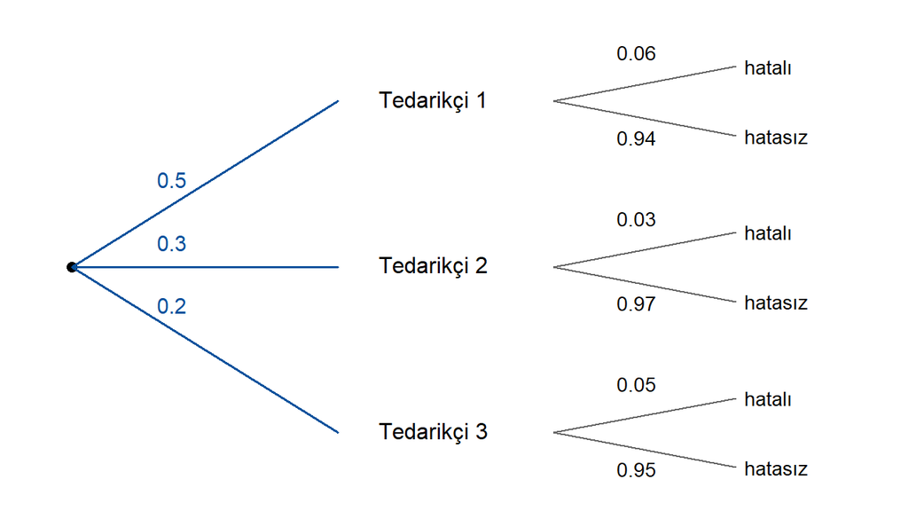

Dört ondalıkla:

- Rassal seçilen birimin “hatalı” dalında olma olasılığı:
- “hatalı” olduğu bilinen birimin Tedarikçi 3 grubundan olma olasılığı:

**Toplam olasılık kuralı:** gruplar ayrık ve bütünü kapsayıcı (bir parçalanış). Her yolun olasılığı dallardaki olasılıkların çarpımıdır; “hatalı” ile biten yollar toplanır:

$$\mathbb{P}(K) = 0.5 \times 0.06 + 0.3 \times 0.03 + 0.2 \times 0.05 = 0.0300 + 0.0090 + 0.0100 = 0.0490$$

**Bayes kuralı:** koşulu tersine çeviriyoruz; payda yukarıda bulduğumuz toplamdır:

$$\mathbb{P}(\text{Tedarikçi 3} \mid K) = \frac{\mathbb{P}(K \mid \text{Tedarikçi 3})\,\mathbb{P}(\text{Tedarikçi 3})}{\mathbb{P}(K)} = \frac{0.0100}{0.0490} = 0.2041$$

Önsel olasılık 0.2 idi; “hatalı” bilgisi onu 0.2041 değerine yükseltti: bu grubun koşullu oranı ortalamanın üstünde.

Bir firma bir parçayı üç tedarikçiden alıyor. Ağaç diyagramında ilk dallar grupların payını, ikinci dallar her gruptaki koşullu olasılıkları gösteriyor.

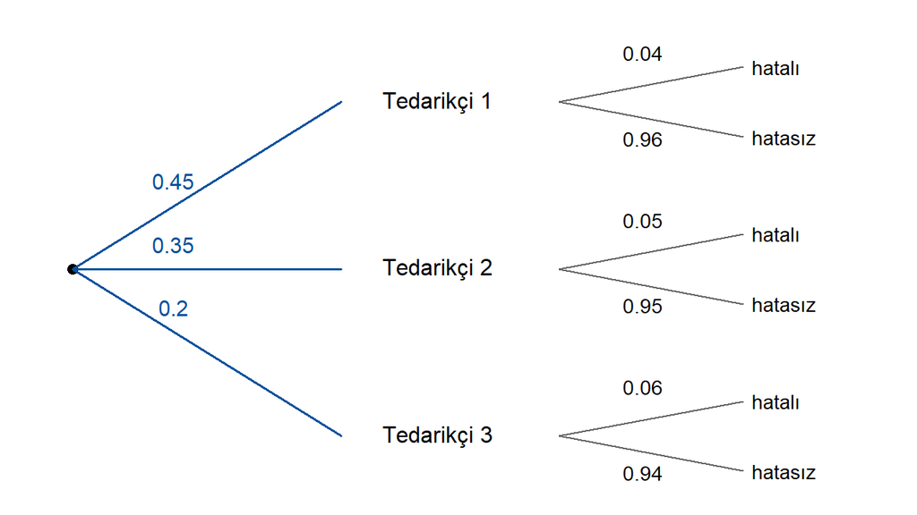

Dört ondalıkla:

- Rassal seçilen birimin “hatalı” dalında olma olasılığı:
- “hatalı” olduğu bilinen birimin Tedarikçi 2 grubundan olma olasılığı:

**Toplam olasılık kuralı:** gruplar ayrık ve bütünü kapsayıcı (bir parçalanış). Her yolun olasılığı dallardaki olasılıkların çarpımıdır; “hatalı” ile biten yollar toplanır:

$$\mathbb{P}(K) = 0.45 \times 0.04 + 0.35 \times 0.05 + 0.2 \times 0.06 = 0.0180 + 0.0175 + 0.0120 = 0.0475$$

**Bayes kuralı:** koşulu tersine çeviriyoruz; payda yukarıda bulduğumuz toplamdır:

$$\mathbb{P}(\text{Tedarikçi 2} \mid K) = \frac{\mathbb{P}(K \mid \text{Tedarikçi 2})\,\mathbb{P}(\text{Tedarikçi 2})}{\mathbb{P}(K)} = \frac{0.0175}{0.0475} = 0.3684$$

Önsel olasılık 0.35 idi; “hatalı” bilgisi onu 0.3684 değerine yükseltti: bu grubun koşullu oranı ortalamanın üstünde.

Bir firma bir parçayı üç tedarikçiden alıyor. Ağaç diyagramında ilk dallar grupların payını, ikinci dallar her gruptaki koşullu olasılıkları gösteriyor.

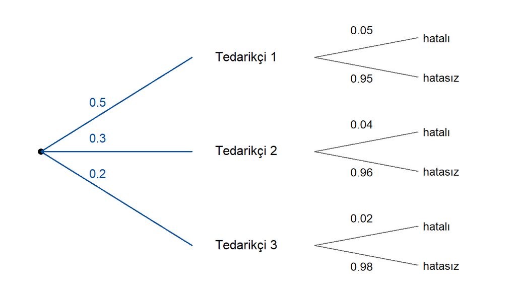

Dört ondalıkla:

- Rassal seçilen birimin “hatalı” dalında olma olasılığı:
- “hatalı” olduğu bilinen birimin Tedarikçi 1 grubundan olma olasılığı:

**Toplam olasılık kuralı:** gruplar ayrık ve bütünü kapsayıcı (bir parçalanış). Her yolun olasılığı dallardaki olasılıkların çarpımıdır; “hatalı” ile biten yollar toplanır:

$$\mathbb{P}(K) = 0.5 \times 0.05 + 0.3 \times 0.04 + 0.2 \times 0.02 = 0.0250 + 0.0120 + 0.0040 = 0.0410$$

**Bayes kuralı:** koşulu tersine çeviriyoruz; payda yukarıda bulduğumuz toplamdır:

$$\mathbb{P}(\text{Tedarikçi 1} \mid K) = \frac{\mathbb{P}(K \mid \text{Tedarikçi 1})\,\mathbb{P}(\text{Tedarikçi 1})}{\mathbb{P}(K)} = \frac{0.0250}{0.0410} = 0.6098$$

Önsel olasılık 0.5 idi; “hatalı” bilgisi onu 0.6098 değerine yükseltti: bu grubun koşullu oranı ortalamanın üstünde.

Bir marketin müşterileri ve organik ürün satın alma. Ağaç diyagramında ilk dallar grupların payını, ikinci dallar her gruptaki koşullu olasılıkları gösteriyor.

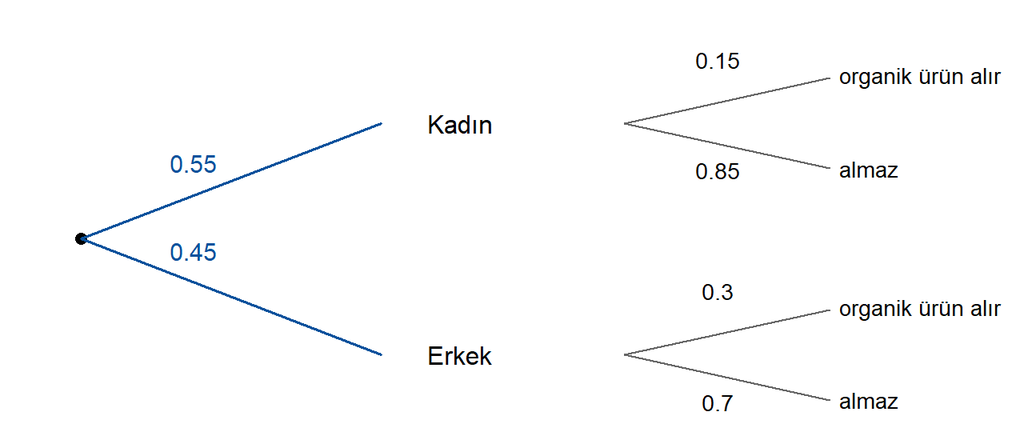

Dört ondalıkla:

- Rassal seçilen birimin “organik ürün alır” dalında olma olasılığı:
- “organik ürün alır” olduğu bilinen birimin Erkek grubundan olma olasılığı:

**Toplam olasılık kuralı:** gruplar ayrık ve bütünü kapsayıcı (bir parçalanış). Her yolun olasılığı dallardaki olasılıkların çarpımıdır; “organik ürün alır” ile biten yollar toplanır:

$$\mathbb{P}(K) = 0.55 \times 0.15 + 0.45 \times 0.3 = 0.0825 + 0.1350 = 0.2175$$

**Bayes kuralı:** koşulu tersine çeviriyoruz; payda yukarıda bulduğumuz toplamdır:

$$\mathbb{P}(\text{Erkek} \mid K) = \frac{\mathbb{P}(K \mid \text{Erkek})\,\mathbb{P}(\text{Erkek})}{\mathbb{P}(K)} = \frac{0.1350}{0.2175} = 0.6207$$

Önsel olasılık 0.45 idi; “organik ürün alır” bilgisi onu 0.6207 değerine yükseltti: bu grubun koşullu oranı ortalamanın üstünde.

Bir kredi kartı şirketinde sahte işlemlerin oranı %2. Bir algoritma sahte işlemleri %98 olasılıkla işaretliyor; gerçek işlemleri de %5 olasılıkla yanlışlıkla işaretliyor. Dört ondalıkla:

- Rassal seçilen birinde sonucun “işaretli” olma olasılığı:
- Sonucu “işaretli” olanın gerçekten sahte olma olasılığı:
- Sonucu “işaretsiz” olanın gerçekten gerçek olma olasılığı:

$H$: sahte, $T^+$: işaretli. Verilenler: $\mathbb{P}(H) = 0.02$, $\mathbb{P}(T^+ \mid H) = 0.98$, $\mathbb{P}(T^+ \mid \bar{H}) = 0.05$.

**Toplam olasılık:**
$$\mathbb{P}(T^+) = 0.98 \times 0.02 + 0.05 \times 0.98 = 0.01960 + 0.04900 = 0.0686$$

**Bayes:**
$$\mathbb{P}(H \mid T^+) = \frac{0.01960}{0.0686} = 0.2857$$

$$\mathbb{P}(\bar{H} \mid T^-) = \frac{\mathbb{P}(T^- \mid \bar{H})\,\mathbb{P}(\bar{H})}{\mathbb{P}(T^-)} = \frac{0.95 \times 0.98}{1 - 0.0686} = 0.9996$$

**100.000 birimle düşünün:** 2.000 tanesi sahte; bunların 1.960 tanesinde sonuç “işaretli”. 98.000 gerçek birimin 4.900 tanesinde de sonuç yanlışlıkla “işaretli”. “işaretli” olan 6.860 birimden yalnızca 1.960 tanesi gerçekten sahte.

Duyarlılık yüksek olsa da durum **nadir** olduğunda yanlış pozitifler gerçek pozitifleri sayıca bastırır; pozitif sonucun anlamı, önsel olasılığa (yaygınlığa) çok bağlıdır. Negatif sonuç ise genellikle çok güvenilirdir.

Bir hastalık toplumda %2 oranında görülüyor. Bir tarama testi hastalarda %98 olasılıkla pozitif sonuç veriyor; hasta olmayanlarda ise %5 olasılıkla yanlışlıkla pozitif sonuç veriyor. Dört ondalıkla:

- Rassal seçilen birinde sonucun “test pozitif” olma olasılığı:
- Sonucu “test pozitif” olanın gerçekten hasta olma olasılığı:
- Sonucu “test negatif” olanın gerçekten hasta olmayan olma olasılığı:

$H$: hasta, $T^+$: test pozitif. Verilenler: $\mathbb{P}(H) = 0.02$, $\mathbb{P}(T^+ \mid H) = 0.98$, $\mathbb{P}(T^+ \mid \bar{H}) = 0.05$.

**Toplam olasılık:**
$$\mathbb{P}(T^+) = 0.98 \times 0.02 + 0.05 \times 0.98 = 0.01960 + 0.04900 = 0.0686$$

**Bayes:**
$$\mathbb{P}(H \mid T^+) = \frac{0.01960}{0.0686} = 0.2857$$

$$\mathbb{P}(\bar{H} \mid T^-) = \frac{\mathbb{P}(T^- \mid \bar{H})\,\mathbb{P}(\bar{H})}{\mathbb{P}(T^-)} = \frac{0.95 \times 0.98}{1 - 0.0686} = 0.9996$$

**100.000 birimle düşünün:** 2.000 tanesi hasta; bunların 1.960 tanesinde sonuç “test pozitif”. 98.000 hasta olmayan birimin 4.900 tanesinde de sonuç yanlışlıkla “test pozitif”. “test pozitif” olan 6.860 birimden yalnızca 1.960 tanesi gerçekten hasta.

Duyarlılık yüksek olsa da durum **nadir** olduğunda yanlış pozitifler gerçek pozitifleri sayıca bastırır; pozitif sonucun anlamı, önsel olasılığa (yaygınlığa) çok bağlıdır. Negatif sonuç ise genellikle çok güvenilirdir.

Bir fabrikadaki makinelerde belirli bir arızanın görülme oranı %5. Bir sensör arızalı makinelerde %98 olasılıkla alarm veriyor; arızasız makinelerde ise %8 olasılıkla yanlış alarm veriyor. Dört ondalıkla:

- Rassal seçilen birinde sonucun “alarm” olma olasılığı:
- Sonucu “alarm” olanın gerçekten arızalı olma olasılığı:
- Sonucu “alarm yok” olanın gerçekten arızasız olma olasılığı:

$H$: arızalı, $T^+$: alarm. Verilenler: $\mathbb{P}(H) = 0.05$, $\mathbb{P}(T^+ \mid H) = 0.98$, $\mathbb{P}(T^+ \mid \bar{H}) = 0.08$.

**Toplam olasılık:**
$$\mathbb{P}(T^+) = 0.98 \times 0.05 + 0.08 \times 0.95 = 0.04900 + 0.07600 = 0.1250$$

**Bayes:**
$$\mathbb{P}(H \mid T^+) = \frac{0.04900}{0.1250} = 0.3920$$

$$\mathbb{P}(\bar{H} \mid T^-) = \frac{\mathbb{P}(T^- \mid \bar{H})\,\mathbb{P}(\bar{H})}{\mathbb{P}(T^-)} = \frac{0.92 \times 0.95}{1 - 0.1250} = 0.9989$$

**100.000 birimle düşünün:** 5.000 tanesi arızalı; bunların 4.900 tanesinde sonuç “alarm”. 95.000 arızasız birimin 7.600 tanesinde de sonuç yanlışlıkla “alarm”. “alarm” olan 12.500 birimden yalnızca 4.900 tanesi gerçekten arızalı.

Duyarlılık yüksek olsa da durum **nadir** olduğunda yanlış pozitifler gerçek pozitifleri sayıca bastırır; pozitif sonucun anlamı, önsel olasılığa (yaygınlığa) çok bağlıdır. Negatif sonuç ise genellikle çok güvenilirdir.

Bir kredi kartı şirketinde sahte işlemlerin oranı %2. Bir algoritma sahte işlemleri %98 olasılıkla işaretliyor; gerçek işlemleri de %2 olasılıkla yanlışlıkla işaretliyor. Dört ondalıkla:

- Rassal seçilen birinde sonucun “işaretli” olma olasılığı:
- Sonucu “işaretli” olanın gerçekten sahte olma olasılığı:
- Sonucu “işaretsiz” olanın gerçekten gerçek olma olasılığı:

$H$: sahte, $T^+$: işaretli. Verilenler: $\mathbb{P}(H) = 0.02$, $\mathbb{P}(T^+ \mid H) = 0.98$, $\mathbb{P}(T^+ \mid \bar{H}) = 0.02$.

**Toplam olasılık:**
$$\mathbb{P}(T^+) = 0.98 \times 0.02 + 0.02 \times 0.98 = 0.01960 + 0.01960 = 0.0392$$

**Bayes:**
$$\mathbb{P}(H \mid T^+) = \frac{0.01960}{0.0392} = 0.5000$$

$$\mathbb{P}(\bar{H} \mid T^-) = \frac{\mathbb{P}(T^- \mid \bar{H})\,\mathbb{P}(\bar{H})}{\mathbb{P}(T^-)} = \frac{0.98 \times 0.98}{1 - 0.0392} = 0.9996$$

**100.000 birimle düşünün:** 2.000 tanesi sahte; bunların 1.960 tanesinde sonuç “işaretli”. 98.000 gerçek birimin 1.960 tanesinde de sonuç yanlışlıkla “işaretli”. “işaretli” olan 3.920 birimden yalnızca 1.960 tanesi gerçekten sahte.

Elinizde iki madeni para var: biri hilesiz, öteki hileli ve tura gelme olasılığı 0.9. Paralardan birini rassal olarak (her birini 1/2 olasılıkla) seçip 3 kez atıyorsunuz; 3 atışın hepsi **tura** geliyor. Atışlar birbirinden bağımsız. Dört ondalıkla:

- 3 atışın hepsinin tura gelme olasılığı (para seçilmeden önce):
- Hepsi tura geldiğine göre seçtiğiniz paranın **hilesiz** olma olasılığı:

$F$: hilesiz para, $H$: hileli para, $T_n$: 3 atışın hepsi tura. Atışlar bağımsız olduğu için her para için olasılıklar çarpılır: $\mathbb{P}(T_n \mid F) = 0.5^{3} = 0.125000$, $\;\mathbb{P}(T_n \mid H) = 0.9^{3} = 0.729000$.

**Toplam olasılık:**
$$\mathbb{P}(T_n) = 0.5 \times 0.125000 + 0.5 \times 0.729000 = 0.4270$$

**Bayes:**
$$\mathbb{P}(F \mid T_n) = \frac{0.5 \times 0.125000}{0.4270} = 0.1464$$

Önsel olasılık 0.5 idi; üst üste tura görmek hilesiz para lehine olan inancı 0.1464 değerine indirdi. Atış sayısı arttıkça ve hep tura geldikçe bu olasılık sıfıra yaklaşır: Bayes kuralı, her yeni gözlemle inancın nasıl güncelleneceğini gösterir.

Elinizde iki madeni para var: biri hilesiz, öteki hileli ve tura gelme olasılığı 0.75. Paralardan birini rassal olarak (her birini 1/2 olasılıkla) seçip 2 kez atıyorsunuz; 2 atışın hepsi **tura** geliyor. Atışlar birbirinden bağımsız. Dört ondalıkla:

- 2 atışın hepsinin tura gelme olasılığı (para seçilmeden önce):
- Hepsi tura geldiğine göre seçtiğiniz paranın **hilesiz** olma olasılığı:

$F$: hilesiz para, $H$: hileli para, $T_n$: 2 atışın hepsi tura. Atışlar bağımsız olduğu için her para için olasılıklar çarpılır: $\mathbb{P}(T_n \mid F) = 0.5^{2} = 0.250000$, $\;\mathbb{P}(T_n \mid H) = 0.75^{2} = 0.562500$.

**Toplam olasılık:**
$$\mathbb{P}(T_n) = 0.5 \times 0.250000 + 0.5 \times 0.562500 = 0.4062$$

**Bayes:**
$$\mathbb{P}(F \mid T_n) = \frac{0.5 \times 0.250000}{0.4062} = 0.3077$$

Önsel olasılık 0.5 idi; üst üste tura görmek hilesiz para lehine olan inancı 0.3077 değerine indirdi. Atış sayısı arttıkça ve hep tura geldikçe bu olasılık sıfıra yaklaşır: Bayes kuralı, her yeni gözlemle inancın nasıl güncelleneceğini gösterir.

Elinizde iki madeni para var: biri hilesiz, öteki hileli ve tura gelme olasılığı 0.9. Paralardan birini rassal olarak (her birini 1/2 olasılıkla) seçip 2 kez atıyorsunuz; 2 atışın hepsi **tura** geliyor. Atışlar birbirinden bağımsız. Dört ondalıkla:

- 2 atışın hepsinin tura gelme olasılığı (para seçilmeden önce):
- Hepsi tura geldiğine göre seçtiğiniz paranın **hilesiz** olma olasılığı:

$F$: hilesiz para, $H$: hileli para, $T_n$: 2 atışın hepsi tura. Atışlar bağımsız olduğu için her para için olasılıklar çarpılır: $\mathbb{P}(T_n \mid F) = 0.5^{2} = 0.250000$, $\;\mathbb{P}(T_n \mid H) = 0.9^{2} = 0.810000$.

**Toplam olasılık:**
$$\mathbb{P}(T_n) = 0.5 \times 0.250000 + 0.5 \times 0.810000 = 0.5300$$

**Bayes:**
$$\mathbb{P}(F \mid T_n) = \frac{0.5 \times 0.250000}{0.5300} = 0.2358$$

Önsel olasılık 0.5 idi; üst üste tura görmek hilesiz para lehine olan inancı 0.2358 değerine indirdi. Atış sayısı arttıkça ve hep tura geldikçe bu olasılık sıfıra yaklaşır: Bayes kuralı, her yeni gözlemle inancın nasıl güncelleneceğini gösterir.

Elinizde iki madeni para var: biri hilesiz, öteki hileli ve tura gelme olasılığı 0.75. Paralardan birini rassal olarak (her birini 1/2 olasılıkla) seçip 2 kez atıyorsunuz; 2 atışın hepsi **tura** geliyor. Atışlar birbirinden bağımsız. Dört ondalıkla:

- 2 atışın hepsinin tura gelme olasılığı (para seçilmeden önce):
- Hepsi tura geldiğine göre seçtiğiniz paranın **hilesiz** olma olasılığı:

$F$: hilesiz para, $H$: hileli para, $T_n$: 2 atışın hepsi tura. Atışlar bağımsız olduğu için her para için olasılıklar çarpılır: $\mathbb{P}(T_n \mid F) = 0.5^{2} = 0.250000$, $\;\mathbb{P}(T_n \mid H) = 0.75^{2} = 0.562500$.

**Toplam olasılık:**
$$\mathbb{P}(T_n) = 0.5 \times 0.250000 + 0.5 \times 0.562500 = 0.4062$$

**Bayes:**
$$\mathbb{P}(F \mid T_n) = \frac{0.5 \times 0.250000}{0.4062} = 0.3077$$

Önsel olasılık 0.5 idi; üst üste tura görmek hilesiz para lehine olan inancı 0.3077 değerine indirdi. Atış sayısı arttıkça ve hep tura geldikçe bu olasılık sıfıra yaklaşır: Bayes kuralı, her yeni gözlemle inancın nasıl güncelleneceğini gösterir.

## Yanılgıları yakalama

Aşağıdaki ifadelerden **doğru olanların hepsini** işaretleyiniz.

Monty Hall probleminde seçimini değiştiren yarışmacı arabayı 2/3 olasılıkla kazanır.Olasılıkları sıfırdan büyük iki ayrık olay bağımsız olamaz.Her $A$ ve $B$ için $\mathbb{P}(A \mid B) = \mathbb{P}(B \mid A)$ olur.Bir test hastaların %95’inde pozitif sonuç veriyorsa, testi pozitif çıkan birinin hasta olma olasılığı %95’tir.Yerine koyarak yapılan çekilişler birbirinden bağımsızdır.

Her ifadenin değerlendirmesi aşağıdadır. Yanlış bir ifadeyi işaretlediyseniz neden yanlış olduğunu kendi cümlelerinizle yazmayı deneyin.

- **Doğru.** Değiştirmek, ilk seçim yanlışsa (olasılık 2/3) kazandırır; sunucunun açtığı kapı bilgi taşır.
- **Doğru.** Biri gerçekleşince öteki kesinlikle gerçekleşmez: $\mathbb{P}(B \mid A) = 0 \neq \mathbb{P}(B)$.
- **Yanlış.** Payları aynı ($\mathbb{P}(A \cap B)$), paydaları farklıdır; ancak $\mathbb{P}(A) = \mathbb{P}(B)$ ise eşitlerdir.
- **Yanlış.** Bu $\mathbb{P}(T^+ \mid H)$ ile $\mathbb{P}(H \mid T^+)$’yı karıştırmaktır; ikincisi yaygınlığa ve yanlış pozitif oranına bağlıdır, nadir hastalıklarda çok düşük olabilir.
- **Doğru.** Top geri konduğu için her çekilişte torba aynıdır.

Aşağıdaki ifadelerden **doğru olanların hepsini** işaretleyiniz.

$\mathbb{P}(A \cap B) = \mathbb{P}(A)\,\mathbb{P}(B)$ her zaman doğrudur.Ayrık olaylar bağımsızdır.Her $A$ ve $B$ için ($\mathbb{P}(B) > 0$) $\mathbb{P}(A \mid B) + \mathbb{P}(\bar{A} \mid B) = 1$ olur.$A$ ile $B$ bağımsızsa $\mathbb{P}(A \mid B) = \mathbb{P}(A)$ olur.Monty Hall probleminde seçimini değiştiren yarışmacı arabayı 2/3 olasılıkla kazanır.

Her ifadenin değerlendirmesi aşağıdadır. Yanlış bir ifadeyi işaretlediyseniz neden yanlış olduğunu kendi cümlelerinizle yazmayı deneyin.

- **Yanlış.** Yalnızca bağımsız olaylar için doğrudur; genel kural $\mathbb{P}(A \cap B) = \mathbb{P}(A)\,\mathbb{P}(B \mid A)$’dır.
- **Yanlış.** Tam tersi: olasılıkları pozitif ayrık olaylar bağımlıdır. Ayrıklık küme, bağımsızlık olasılık özelliğidir.
- **Doğru.** $B$ verilmişken $A$ ile $\bar{A}$ daraltılmış uzayı bölüşür; toplamları 1’dir.
- **Doğru.** Bağımsızlığın tanımı budur: $B$’yi bilmek $A$’nın olasılığını değiştirmez.
- **Doğru.** Değiştirmek, ilk seçim yanlışsa (olasılık 2/3) kazandırır; sunucunun açtığı kapı bilgi taşır.

Aşağıdaki ifadelerden **doğru olanların hepsini** işaretleyiniz.

Olasılıkları sıfırdan büyük iki ayrık olay bağımsız olamaz.Monty Hall probleminde sunucu bir kapıyı açtıktan sonra iki kapı kaldığı için kazanma olasılığı 1/2’dir.Yerine koyarak yapılan çekilişler birbirinden bağımsızdır.Her $A$ ve $B$ için ($\mathbb{P}(B) > 0$) $\mathbb{P}(A \mid B) + \mathbb{P}(\bar{A} \mid B) = 1$ olur.$\mathbb{P}(A \cap B) = \mathbb{P}(A)\,\mathbb{P}(B)$ her zaman doğrudur.

Her ifadenin değerlendirmesi aşağıdadır. Yanlış bir ifadeyi işaretlediyseniz neden yanlış olduğunu kendi cümlelerinizle yazmayı deneyin.

- **Doğru.** Biri gerçekleşince öteki kesinlikle gerçekleşmez: $\mathbb{P}(B \mid A) = 0 \neq \mathbb{P}(B)$.
- **Yanlış.** İki kapının eşit olasılıklı olduğu varsayımı yanlıştır; sunucu bilerek keçili kapıyı açar.
- **Doğru.** Top geri konduğu için her çekilişte torba aynıdır.
- **Doğru.** $B$ verilmişken $A$ ile $\bar{A}$ daraltılmış uzayı bölüşür; toplamları 1’dir.
- **Yanlış.** Yalnızca bağımsız olaylar için doğrudur; genel kural $\mathbb{P}(A \cap B) = \mathbb{P}(A)\,\mathbb{P}(B \mid A)$’dır.

Aşağıdaki ifadelerden **doğru olanların hepsini** işaretleyiniz.

Olasılıkları sıfırdan büyük iki ayrık olay bağımsız olamaz.Yerine koyarak yapılan çekilişler birbirinden bağımsızdır.$\mathbb{P}(A \cap B) = \mathbb{P}(A)\,\mathbb{P}(B)$ her zaman doğrudur.Bir test hastaların %95’inde pozitif sonuç veriyorsa, testi pozitif çıkan birinin hasta olma olasılığı %95’tir.Her $A$ ve $B$ için $\mathbb{P}(A \mid B) = \mathbb{P}(B \mid A)$ olur.

Her ifadenin değerlendirmesi aşağıdadır. Yanlış bir ifadeyi işaretlediyseniz neden yanlış olduğunu kendi cümlelerinizle yazmayı deneyin.

- **Doğru.** Biri gerçekleşince öteki kesinlikle gerçekleşmez: $\mathbb{P}(B \mid A) = 0 \neq \mathbb{P}(B)$.
- **Doğru.** Top geri konduğu için her çekilişte torba aynıdır.
- **Yanlış.** Yalnızca bağımsız olaylar için doğrudur; genel kural $\mathbb{P}(A \cap B) = \mathbb{P}(A)\,\mathbb{P}(B \mid A)$’dır.
- **Yanlış.** Bu $\mathbb{P}(T^+ \mid H)$ ile $\mathbb{P}(H \mid T^+)$’yı karıştırmaktır; ikincisi yaygınlığa ve yanlış pozitif oranına bağlıdır, nadir hastalıklarda çok düşük olabilir.
- **Yanlış.** Payları aynı ($\mathbb{P}(A \cap B)$), paydaları farklıdır; ancak $\mathbb{P}(A) = \mathbb{P}(B)$ ise eşitlerdir.

Aşağıdaki ifadelerden **doğru olanların hepsini** işaretleyiniz.

Her $A$ ve $B$ için $\mathbb{P}(A \mid B) + \mathbb{P}(A \mid \bar{B}) = 1$ olur.Her $A$ ve $B$ için ($\mathbb{P}(B) > 0$) $\mathbb{P}(A \mid B) + \mathbb{P}(\bar{A} \mid B) = 1$ olur.$A$ ile $B$ bağımsızsa $\mathbb{P}(A \mid B) = \mathbb{P}(A)$ olur.Çapraz tabloda iki değişken bağımsız değilse biri ötekinin nedenidir.Bayes kuralında paydadaki $\mathbb{P}(B)$ genellikle toplam olasılık kuralıyla hesaplanır.

Her ifadenin değerlendirmesi aşağıdadır. Yanlış bir ifadeyi işaretlediyseniz neden yanlış olduğunu kendi cümlelerinizle yazmayı deneyin.

- **Yanlış.** Koşullar farklı olduğu için toplamın 1 olması gerekmez; örneğin $A$ ile $B$ bağımsızsa ve $\mathbb{P}(A) = 0.3$ ise toplam 0.6’dır.
- **Doğru.** $B$ verilmişken $A$ ile $\bar{A}$ daraltılmış uzayı bölüşür; toplamları 1’dir.
- **Doğru.** Bağımsızlığın tanımı budur: $B$’yi bilmek $A$’nın olasılığını değiştirmez.
- **Yanlış.** Bağımlılık olasılıklar arasındaki bir ilişkidir; üçüncü bir değişken ya da ters yönlü bir etki de bu ilişkiyi yaratabilir.
- **Doğru.** $\mathbb{P}(B) = \mathbb{P}(B \mid A)\mathbb{P}(A) + \mathbb{P}(B \mid \bar{A})\mathbb{P}(\bar{A})$.

Aşağıdaki ifadelerden **doğru olanların hepsini** işaretleyiniz.

Monty Hall probleminde seçimini değiştiren yarışmacı arabayı 2/3 olasılıkla kazanır.Yerine koyarak yapılan çekilişler birbirinden bağımsızdır.$A$ ile $B$ bağımsızsa $\mathbb{P}(A \mid B) = \mathbb{P}(A)$ olur.Ayrık olaylar bağımsızdır.$\mathbb{P}(A \cap B) = \mathbb{P}(A)\,\mathbb{P}(B)$ her zaman doğrudur.

Her ifadenin değerlendirmesi aşağıdadır. Yanlış bir ifadeyi işaretlediyseniz neden yanlış olduğunu kendi cümlelerinizle yazmayı deneyin.

- **Doğru.** Değiştirmek, ilk seçim yanlışsa (olasılık 2/3) kazandırır; sunucunun açtığı kapı bilgi taşır.
- **Doğru.** Top geri konduğu için her çekilişte torba aynıdır.
- **Doğru.** Bağımsızlığın tanımı budur: $B$’yi bilmek $A$’nın olasılığını değiştirmez.
- **Yanlış.** Tam tersi: olasılıkları pozitif ayrık olaylar bağımlıdır. Ayrıklık küme, bağımsızlık olasılık özelliğidir.
- **Yanlış.** Yalnızca bağımsız olaylar için doğrudur; genel kural $\mathbb{P}(A \cap B) = \mathbb{P}(A)\,\mathbb{P}(B \mid A)$’dır.

Aşağıdaki ifadelerden **doğru olanların hepsini** işaretleyiniz.

Olasılıkları sıfırdan büyük iki ayrık olay bağımsız olamaz.Bir test hastaların %95’inde pozitif sonuç veriyorsa, testi pozitif çıkan birinin hasta olma olasılığı %95’tir.Her $A$ ve $B$ için $\mathbb{P}(A \mid B) + \mathbb{P}(A \mid \bar{B}) = 1$ olur.Her $A$ ve $B$ için ($\mathbb{P}(B) > 0$) $\mathbb{P}(A \mid B) + \mathbb{P}(\bar{A} \mid B) = 1$ olur.Monty Hall probleminde seçimini değiştiren yarışmacı arabayı 2/3 olasılıkla kazanır.

Her ifadenin değerlendirmesi aşağıdadır. Yanlış bir ifadeyi işaretlediyseniz neden yanlış olduğunu kendi cümlelerinizle yazmayı deneyin.

- **Doğru.** Biri gerçekleşince öteki kesinlikle gerçekleşmez: $\mathbb{P}(B \mid A) = 0 \neq \mathbb{P}(B)$.
- **Yanlış.** Bu $\mathbb{P}(T^+ \mid H)$ ile $\mathbb{P}(H \mid T^+)$’yı karıştırmaktır; ikincisi yaygınlığa ve yanlış pozitif oranına bağlıdır, nadir hastalıklarda çok düşük olabilir.
- **Yanlış.** Koşullar farklı olduğu için toplamın 1 olması gerekmez; örneğin $A$ ile $B$ bağımsızsa ve $\mathbb{P}(A) = 0.3$ ise toplam 0.6’dır.
- **Doğru.** $B$ verilmişken $A$ ile $\bar{A}$ daraltılmış uzayı bölüşür; toplamları 1’dir.
- **Doğru.** Değiştirmek, ilk seçim yanlışsa (olasılık 2/3) kazandırır; sunucunun açtığı kapı bilgi taşır.

Aşağıdaki ifadelerden **doğru olanların hepsini** işaretleyiniz.

Her $A$ ve $B$ için $\mathbb{P}(A \mid B) + \mathbb{P}(A \mid \bar{B}) = 1$ olur.$A$ ile $B$ bağımsızsa $\mathbb{P}(A \mid B) = \mathbb{P}(A)$ olur.Ayrık olaylar bağımsızdır.Yerine koyarak yapılan çekilişler birbirinden bağımsızdır.Monty Hall probleminde seçimini değiştiren yarışmacı arabayı 2/3 olasılıkla kazanır.

Her ifadenin değerlendirmesi aşağıdadır. Yanlış bir ifadeyi işaretlediyseniz neden yanlış olduğunu kendi cümlelerinizle yazmayı deneyin.

- **Yanlış.** Koşullar farklı olduğu için toplamın 1 olması gerekmez; örneğin $A$ ile $B$ bağımsızsa ve $\mathbb{P}(A) = 0.3$ ise toplam 0.6’dır.
- **Doğru.** Bağımsızlığın tanımı budur: $B$’yi bilmek $A$’nın olasılığını değiştirmez.
- **Yanlış.** Tam tersi: olasılıkları pozitif ayrık olaylar bağımlıdır. Ayrıklık küme, bağımsızlık olasılık özelliğidir.
- **Doğru.** Top geri konduğu için her çekilişte torba aynıdır.
- **Doğru.** Değiştirmek, ilk seçim yanlışsa (olasılık 2/3) kazandırır; sunucunun açtığı kapı bilgi taşır.

## Düşünme soruları

Bu soruların tek bir doğru cevabı yok ve otomatik denetlenmez. Önce kendi cevabınızı birkaç cümleyle yazın, sonra örnek cevapla karşılaştırın.

**1. Üç mahkûm.** A, B ve C adlı üç mahkûmdan yalnızca birinin affedileceği, hangisinin affedileceğinin eşit olasılıklı olduğu biliniyor. Kimin affedileceğini bilen müdür, A’nın isteği üzerine B ile C’den idam edilecek olanlardan birinin adını söylüyor: “B idam edilecek” (A affedilecekse müdür B ile C arasından birini eşit olasılıkla söylüyor). A, affedilme olasılığının 1/3’ten 1/2’ye çıktığını düşünüyor. Haklı mı? C’nin affedilme olasılığı nedir? Monty Hall problemiyle ilişkisi nedir?

**NotÖrnek cevap**

A haklı değil. $B_i$: müdürün “B idam edilecek” demesi olsun. Affedilecek kişiye göre bu sözün olasılığı: A affedilecekse 1/2 (müdür B ile C arasından seçiyor), C affedilecekse 1 (tek seçeneği B), B affedilecekse 0. Toplam olasılık: $\mathbb{P}(B_i) = \tfrac{1}{3} \cdot \tfrac{1}{2} + \tfrac{1}{3} \cdot 1 + \tfrac{1}{3} \cdot 0 = \tfrac{1}{2}$. Bayes: $\mathbb{P}(A \text{ affedilir} \mid B_i) = \dfrac{1/6}{1/2} = \tfrac{1}{3}$, $\;\mathbb{P}(C \text{ affedilir} \mid B_i) = \dfrac{1/3}{1/2} = \tfrac{2}{3}$.

A’nın olasılığı değişmez, çünkü müdür A hakkında hiçbir şey söylememiştir; A affedilecek olsa da olmasa da müdür birinin adını verebilir. Ama C’nin olasılığı ikiye katlanır. Bu, Monty Hall’un aynısıdır: A ilk seçilen kapı, müdür bilgili sunucu, C ise “değiştirilecek” kapı.

**2. Toplu tarama.** Toplumun binde birinde görülen bir hastalık için hastaların %99’unda pozitif sonuç veren, sağlıklıların %2’sinde yanlış pozitif veren bir test var. Sağlık bakanlığı bu testin bütün yetişkinlere uygulanmasını düşünüyor. Pozitif sonucun anlamı nedir? Bu politikanın sorunları neler olabilir? Nasıl iyileştirilebilir?

**NotÖrnek cevap**

Bayes kuralıyla $\mathbb{P}(\text{hasta} \mid +) = \dfrac{0.99 \times 0.001}{0.99 \times 0.001 + 0.02 \times 0.999} \approx 0.047$. Yani pozitif sonuç alanların yaklaşık 20’de 19’u aslında sağlıklıdır. Bir milyon kişi taranırsa yaklaşık 1000 hastanın 990’ı yakalanır, ama yaklaşık 20000 sağlıklı kişi de pozitif sonuç alır.

Sorunlar: gereksiz kaygı, ileri tetkiklerin ve tedavilerin maliyeti ve yan etkileri, sağlık sisteminin yükü. İyileştirme yolları: taramayı riski yüksek gruplara uygulamak (önsel olasılık, yani yaygınlık, yükselir ve pozitif sonucun anlamı güçlenir), pozitif çıkanlara ikinci ve daha özgül bir test uygulamak, ya da yanlış pozitif oranı daha düşük bir test kullanmak.

**3. Spam filtresi.** E-postaların %40’ı spam. “Bedava” kelimesi spam e-postaların %30’unda, normal e-postaların %2’sinde geçiyor. İçinde “bedava” geçen bir e-postanın spam olma olasılığı nedir? Bir e-posta filtresi bu fikri nasıl kullanabilir? Tek bir kelimeye bakmak neden yetmez?

**NotÖrnek cevap**

$\mathbb{P}(\text{spam} \mid \text{bedava}) = \dfrac{0.30 \times 0.40}{0.30 \times 0.40 + 0.02 \times 0.60} = \dfrac{0.12}{0.132} \approx 0.91$. Kelimeyi görmek, spam olma olasılığını önsel 0.40’tan 0.91’e yükseltiyor.

Filtre her kelime için spam ve normal e-postalardaki sıklıkları geçmiş veriden öğrenir ve gelen e-postadaki kelimelerle olasılığı Bayes kuralıyla günceller. Tek kelime yetmez: “bedava” normal e-postalarda da geçebilir ve spam gönderenler bu kelimeden kaçınmayı öğrenir. Birçok kelime ve özellik birlikte kullanılır; ayrıca yanlışlıkla spam sayılan önemli bir e-postanın maliyeti ile kaçırılan bir spamın maliyeti farklı olduğundan karar eşiği buna göre seçilir.